# Plan du projet :

**1) Extraction, chargement et nettoyage des données de classement des skippers**

- Récupération des fichiers Excel avec les classements
- Chargement des données dans un DataFrame
- Nettoyage des données de classement des skippers
- Affichage des caractéristiques des données

**2) Extraction, chargement et nettoyage des données sur les caractéristiques techniques des voiliers**

- Téléchargement des données sur les caractéristiques techniques des voiliers et construction du Dataset
- Nettoyage des données sur les caractéristiques techniques des voiliers
- Affichage des caractéristiques des données

**3) Rapprochement des données des voiliers avec celle des classements**

- Préparation des données pour la fusion
- Fusion des DataFrames
- Affichage des caractéristiques des données

**4) Les statistiques de course**

- Statistiques relatives à la vitesse atteinte par les skippers
- Statistiques relatives à la distance parcourue par les skippers
- Statistiques relatives aux rangs des skippers

**5) Analyse statistique**

- Corrélation et régression linéaire entre le classement (rang) et les différentes vitesses utiles (VMG) des voiliers
  - Régression sur toutes les observations
  - Régression sur les données agrégées par nom de voilier
- KMeans sur les caractéristiques techniques des voiliers
  - Prétraitement des données
  - Détermination du nombre de voisins optimal et application de la méthode KMeans
  - Réalisation d'une ACP pour visualiser les résultats
- Impact de la présence d'un foil sur le classement et la vitesse des voiliers
- Visualisation de la distance parcourue par voilier
- Analyse des séries chronologiques
  - Visualisation de la progression du rang de skippers dans le temps
  - Visualisation de la progression de la distance parcourue par les skippers dans le temps

**6) Visualisation du parcours des voiliers sur la carte**

```python
import os
from urllib import request
import shutil
import pandas as pd
import numpy as np
import re
import requests
from bs4 import BeautifulSoup
from datetime import datetime
import statsmodels.api as sm
from scipy.stats import pearsonr
import matplotlib.pyplot as plt
from sklearn.linear_model import LinearRegression
from sklearn.preprocessing import LabelBinarizer, StandardScaler
from sklearn.cluster import KMeans
from sklearn.decomposition import PCA
import seaborn as sns
from random import sample
from plotly.offline import iplot, init_notebook_mode
import plotly.graph_objs as go
```

```python
#customizing pandas display options
pd.set_option('display.max_columns', 50)
pd.set_option('display.width', 1000)
# disable warnings
import warnings
warnings.filterwarnings("ignore")
#customizing matplotlib
plt.style.use('ggplot')
```

# **1) Extraction, chargement et nettoyage des données de classement des skippers**

## Récupération des fichiers Excel avec les classements

```python
resp = requests.get('https://www.vendeeglobe.org/fr/classement')
b_s = BeautifulSoup(resp.content).find("select",
                                       attrs={"class":"form__input m--select onsubmit-rank", "data-uri":"/fr/classement"})
```

```python
# Méthode 1
for date_ranking in b_s.findAll('option'):
    file = 'vendeeglobe_'+ date_ranking.attrs["value"] + '.xlsx'
    url = 'https://www.vendeeglobe.org/download-race-data/vendeeglobe_' + date_ranking.attrs['value'] + '.xlsx'
    request.urlretrieve(url, os.path.join('.','Classements',file))
```

```python
# Méthode 2 (proposée par le prof)
for date_ranking in b_s.findAll('option'):
    file = 'vendeeglobe_'+ date_ranking.attrs["value"] + '.xlsx'
    url = 'https://www.vendeeglobe.org/download-race-data/vendeeglobe_' + date_ranking.attrs['value'] + '.xlsx'
    with request.urlopen(url) as response, open(os.path.join('.','Classements',file), 'wb') as out_file:
        shutil.copyfileobj(response, out_file)
```

En utilisant les 2 méthodes, j'arrive pas à télécharger les fichiers Excel à partir du site web. A chaque fois, j'ai l'erreur suivante :

[figure not shown]

En me documentant là-dessus, j'ai trouvé que le certificat du site n'est plus valide (a expiré) il y a quelques jours.

[figure not shown]

Face à ce problème, et malgré le fait que les 2 méthodes ne contiennent pas d'erreur, j'ai téléchargé tous les fichiers Excel manuellement.

## Chargement des données dans un DataFrame

```python
path = './Classements'
files = [os.path.join(path, x) for x in os.listdir(path)]
stop_index = files.index(os.path.join(path, "vendeeglobe_20210127_170000.xlsx"))
files = files[:stop_index] ## only rankings before first arrival
df = pd.DataFrame()
for file in files :
    df0 = pd.read_excel(file, header=0, usecols="B:U", skiprows=4, skipfooter=6, engine="openpyxl",
                        names=['Rang', 'Nat./Voile', 'Skipper/Bateau','Heure_FR','Latitude','Longitude','Cap_30min',
                                'Vitesse_30min', 'VMG_30min','Distance_30min','Cap_last','Vitesse_last','VMG_last',
                               'Distance_last','Cap_24h','Vitesse_24h','VMG_24h','Distance_24h','DTF','DTL'])
    df0.insert(0, 'Date_classement', ''.join(re.findall('_(.*).xlsx', file)))  ## ''.joint() to convert one-element list to string
    df = df.append(df0, ignore_index=True)
```

```python
df_ = df.copy()
```

```python
df_.head(40)
```

|  | Date_classement | Rang | Nat./Voile | Skipper/Bateau | Heure_FR | Latitude | Longitude | Cap_30min | Vitesse_30min | VMG_30min | Distance_30min | Cap_last | Vitesse_last | VMG_last | Distance_last | Cap_24h | Vitesse_24h | VMG_24h | Distance_24h | DTF | DTL |
| --- | --- | --- | --- | --- | --- | --- | --- | --- | --- | --- | --- | --- | --- | --- | --- | --- | --- | --- | --- | --- | --- |
| 0 | 20201108_170000 | 1 | \nFRA 8 | Jérémie Beyou\nCharal | 18:30 FR\n | 46°19.75'N | 03°27.02'W | 268° | 20.2 kts | 16.8 kts | 10.1 nm | 268° | 23.7 kts | 20.6 kts | 35.6 nm | 261° | 3.0 kts | 2.8 kts | 69.5 nm | 24234.9 nm | 0.0 nm |
| 1 | 20201108_170000 | 2 | \nFRA 79 | Charlie Dalin\nAPIVIA | 18:30 FR\n | 46°15.92'N | 03°21.99'W | 266° | 20.1 kts | 17.3 kts | 10.1 nm | 267° | 23.3 kts | 20.6 kts | 35.0 nm | 257° | 2.8 kts | 2.7 kts | 66.8 nm | 24235.6 nm | 0.6 nm |
| 2 | 20201108_170000 | 3 | \nFRA 59 | Thomas Ruyant\nLinkedOut | 18:30 FR\n | 46°19.06'N | 03°24.12'W | 265° | 20.9 kts | 18.0 kts | 10.4 nm | 269° | 23.9 kts | 20.6 kts | 35.8 nm | 260° | 2.9 kts | 2.7 kts | 67.6 nm | 24236.2 nm | 1.2 nm |
| 3 | 20201108_170000 | 4 | \nGBR 99 | Alex Thomson\nHugo Boss | 18:30 FR\n | 46°15.33'N | 03°18.94'W | 265° | 20.2 kts | 17.6 kts | 10.1 nm | 264° | 21.9 kts | 19.9 kts | 32.9 nm | 256° | 2.8 kts | 2.7 kts | 64.9 nm | 24237.0 nm | 2.0 nm |
| 4 | 20201108_170000 | 5 | \nMON 10 | Boris Herrmann\nSeaexplorer - Yacht Club De Mo... | 18:30 FR\n | 46°17.04'N | 03°18.71'W | 269° | 18.8 kts | 15.7 kts | 9.4 nm | 268° | 22.6 kts | 19.9 kts | 34.0 nm | 258° | 2.7 kts | 2.6 kts | 64.3 nm | 24238.1 nm | 3.1 nm |
| 5 | 20201108_170000 | 6 | \nFRA 6 | Nicolas Troussel\nCORUM L'Épargne | 18:30 FR\n | 46°22.46'N | 03°22.50'W | 266° | 21.0 kts | 17.9 kts | 10.5 nm | 271° | 22.9 kts | 19.4 kts | 34.3 nm | 263° | 2.8 kts | 2.6 kts | 66.0 nm | 24239.0 nm | 4.1 nm |
| 6 | 20201108_170000 | 7 | FR\nFRA 02 | Armel Tripon\nL'Occitane en Provence | 18:30 FR\n | 46°21.29'N | 03°19.94'W | 270° | 21.9 kts | 17.8 kts | 10.9 nm | 271° | 23.6 kts | 20.0 kts | 35.4 nm | 262° | 2.7 kts | 2.6 kts | 64.4 nm | 24239.8 nm | 4.9 nm |
| 7 | 20201108_170000 | 8 | \nFRA 4 | Sébastien Simon\nARKEA PAPREC | 18:30 FR\n | 46°16.47'N | 03°13.69'W | 269° | 18.5 kts | 15.5 kts | 9.2 nm | 267° | 20.9 kts | 18.5 kts | 31.4 nm | 257° | 2.6 kts | 2.5 kts | 61.1 nm | 24240.6 nm | 5.7 nm |
| 8 | 20201108_170000 | 9 | \nFRA 17 | Yannick Bestaven\nMaître Coq IV | 18:30 FR\n | 46°14.56'N | 03°10.61'W | 268° | 20.2 kts | 17.2 kts | 10.1 nm | 264° | 21.6 kts | 19.6 kts | 32.4 nm | 254° | 2.5 kts | 2.5 kts | 59.5 nm | 24241.3 nm | 6.4 nm |
| 9 | 20201108_170000 | 10 | \nFRA 109 | Samantha Davies\nInitiatives - Coeur | 18:30 FR\n | 46°20.94'N | 03°16.55'W | 271° | 19.9 kts | 16.1 kts | 9.9 nm | 270° | 21.6 kts | 18.4 kts | 32.4 nm | 261° | 5.9 kts | 5.5 kts | 62.2 nm | 24241.5 nm | 6.6 nm |
| 10 | 20201108_170000 | 11 | \nFRA 18 | Louis Burton\nBureau Vallée 2 | 18:30 FR\n | 46°21.73'N | 03°17.02'W | 271° | 20.3 kts | 16.4 kts | 10.2 nm | 271° | 21.5 kts | 18.3 kts | 32.3 nm | 262° | 2.7 kts | 2.5 kts | 62.4 nm | 24241.7 nm | 6.8 nm |
| 11 | 20201108_170000 | 12 | \nJPN 11 | Kojiro Shiraishi\nDMG MORI Global One | 18:30 FR\n | 46°19.15'N | 03°11.77'W | 269° | 19.9 kts | 16.6 kts | 9.9 nm | 267° | 22.1 kts | 19.5 kts | 33.2 nm | 259° | 2.5 kts | 2.4 kts | 59.3 nm | 24243.2 nm | 8.3 nm |
| 12 | 20201108_170000 | 13 | \nITA 34 | Giancarlo Pedote\nPrysmian Group | 18:30 FR\n | 46°13.38'N | 03°05.59'W | 262° | 19.3 kts | 17.5 kts | 9.7 nm | 260° | 20.2 kts | 19.0 kts | 30.3 nm | 252° | 2.4 kts | 2.4 kts | 56.6 nm | 24243.6 nm | 8.7 nm |
| 13 | 20201108_170000 | 14 | \nFRA 85 | Kevin Escoffier\nPRB | 18:30 FR\n | 46°21.47'N | 03°13.08'W | 272° | 19.5 kts | 15.6 kts | 9.8 nm | 270° | 21.4 kts | 18.2 kts | 32.1 nm | 261° | 2.5 kts | 2.4 kts | 59.7 nm | 24243.8 nm | 8.9 nm |
| 14 | 20201108_170000 | 15 | \nFRA 27 | Isabelle Joschke\nMACSF | 18:30 FR\n | 46°19.27'N | 03°10.22'W | 272° | 19.8 kts | 16.0 kts | 9.9 nm | 269° | 21.6 kts | 18.8 kts | 32.4 nm | 259° | 2.5 kts | 2.4 kts | 58.2 nm | 24244.2 nm | 9.2 nm |
| 15 | 20201108_170000 | 16 | \nFRA 53 | Maxime Sorel\nV And B Mayenne | 18:30 FR\n | 46°14.24'N | 03°04.87'W | 262° | 18.7 kts | 17.0 kts | 9.4 nm | 262° | 19.2 kts | 17.8 kts | 28.9 nm | 253° | 5.4 kts | 5.2 kts | 55.8 nm | 24244.5 nm | 9.5 nm |
| 16 | 20201108_170000 | 17 | \nFRA 1000 | Damien Seguin\nGroupe APICIL | 18:30 FR\n | 46°11.80'N | 03°02.30'W | 260° | 19.1 kts | 17.6 kts | 9.5 nm | 258° | 19.1 kts | 18.1 kts | 28.6 nm | 250° | 2.3 kts | 2.3 kts | 54.9 nm | 24244.7 nm | 9.7 nm |
| 17 | 20201108_170000 | 18 | \nFRA 01 | Jean Le Cam\nYes we Cam ! | 18:30 FR\n | 46°07.77'N | 02°58.48'W | 255° | 19.0 kts | 18.2 kts | 9.5 nm | 254° | 18.9 kts | 18.4 kts | 28.4 nm | 245° | 2.3 kts | 2.3 kts | 54.0 nm | 24244.8 nm | 9.8 nm |
| 18 | 20201108_170000 | 19 | \nFRA 92 | Stéphane Le Diraison\nTime For Oceans | 18:30 FR\n | 46°14.21'N | 03°04.04'W | 261° | 19.1 kts | 17.4 kts | 9.5 nm | 262° | 20.1 kts | 18.6 kts | 30.1 nm | 253° | 2.4 kts | 2.3 kts | 55.3 nm | 24244.9 nm | 10.0 nm |
| 19 | 20201108_170000 | 20 | \nFRA 30 | Clarisse Cremer\nBanque Populaire X | 18:30 FR\n | 46°15.64'N | 03°01.98'W | 265° | 18.2 kts | 16.1 kts | 9.1 nm | 263° | 18.8 kts | 17.3 kts | 28.2 nm | 254° | 5.1 kts | 5.0 kts | 53.5 nm | 24246.9 nm | 12.0 nm |
| 20 | 20201108_170000 | 21 | \nFRA 49 | Romain Attanasio\nPure - Best Western Hotels a... | 18:30 FR\n | 46°17.93'N | 03°00.09'W | 270° | 16.9 kts | 14.1 kts | 8.4 nm | 267° | 17.6 kts | 15.6 kts | 26.4 nm | 256° | 2.2 kts | 2.1 kts | 51.7 nm | 24249.3 nm | 14.3 nm |
| 21 | 20201108_170000 | 22 | \nSUI 7 | Alan Roura\nLa Fabrique | 18:30 FR\n | 46°22.88'N | 03°03.58'W | 275° | 19.9 kts | 15.4 kts | 9.9 nm | 273° | 19.3 kts | 16.1 kts | 28.9 nm | 262° | 2.3 kts | 2.1 kts | 53.0 nm | 24250.0 nm | 15.1 nm |
| 22 | 20201108_170000 | 23 | \nFRA 09 | Benjamin Dutreux\nOMIA - Water Family | 18:30 FR\n | 46°19.31'N | 02°59.42'W | 267° | 18.5 kts | 16.0 kts | 9.3 nm | 266° | 18.1 kts | 16.3 kts | 27.2 nm | 257° | 2.2 kts | 2.1 kts | 50.9 nm | 24250.4 nm | 15.5 nm |
| 23 | 20201108_170000 | 24 | \nFRA 56 | Fabrice Amedeo\nNewrest - Art et Fenetres | 18:30 FR\n | 46°24.15'N | 03°03.25'W | 287° | 12.3 kts | 7.7 kts | 6.2 nm | 276° | 17.2 kts | 13.8 kts | 25.8 nm | 263° | 2.2 kts | 2.1 kts | 52.7 nm | 24250.9 nm | 16.0 nm |
| 24 | 20201108_170000 | 25 | \nFRA 50 | Miranda Merron\nCampagne de France | 18:30 FR\n | 46°10.41'N | 02°47.82'W | 253° | 16.7 kts | 16.2 kts | 8.3 nm | 251° | 16.4 kts | 16.2 kts | 24.6 nm | 244° | 2.0 kts | 2.0 kts | 46.2 nm | 24252.5 nm | 17.5 nm |
| 25 | 20201108_170000 | 26 | \nFRA 71 | Manuel Cousin\nGroupe Sétin | 18:30 FR\n | 46°12.33'N | 02°49.49'W | 257° | 16.8 kts | 16.0 kts | 8.4 nm | 256° | 16.1 kts | 15.5 kts | 24.1 nm | 247° | 2.0 kts | 2.0 kts | 46.5 nm | 24252.5 nm | 17.5 nm |
| 26 | 20201108_170000 | 27 | \nESP 33 | Didac Costa\nOne Planet One Ocean | 18:30 FR\n | 46°17.53'N | 02°53.38'W | 265° | 16.6 kts | 14.7 kts | 8.3 nm | 262° | 16.0 kts | 14.8 kts | 24.1 nm | 254° | 4.9 kts | 4.8 kts | 47.3 nm | 24252.9 nm | 18.0 nm |
| 27 | 20201108_170000 | 28 | \nGBR 777 | Pip Hare\nMedallia | 18:30 FR\n | 46°17.62'N | 02°52.07'W | 265° | 15.9 kts | 14.1 kts | 8.0 nm | 263° | 15.9 kts | 14.6 kts | 23.8 nm | 254° | 2.0 kts | 1.9 kts | 46.4 nm | 24253.8 nm | 18.8 nm |
| 28 | 20201108_170000 | 29 | FR\nFRA 69 | Sébastien Destremau\nMerci | 18:30 FR\n | 46°15.02'N | 02°48.56'W | 259° | 16.2 kts | 15.2 kts | 8.1 nm | 258° | 15.6 kts | 14.8 kts | 23.4 nm | 250° | 1.9 kts | 1.9 kts | 44.9 nm | 24254.4 nm | 19.5 nm |
| 29 | 20201108_170000 | 30 | \nFRA 83 | Clément Giraud\nCompagnie du lit - Jiliti | 18:30 FR\n | 46°09.99'N | 02°41.63'W | 246° | 12.6 kts | 12.5 kts | 6.3 nm | 249° | 13.9 kts | 13.7 kts | 20.8 nm | 241° | 1.8 kts | 1.8 kts | 42.6 nm | 24255.9 nm | 21.0 nm |
| 30 | 20201108_170000 | 31 | \nFRA 72 | Alexia Barrier\nTSE - 4myplanet | 18:30 FR\n | 46°22.43'N | 02°50.89'W | 274° | 16.2 kts | 12.9 kts | 8.1 nm | 272° | 15.4 kts | 13.0 kts | 23.1 nm | 260° | 4.4 kts | 4.1 kts | 44.5 nm | 24257.0 nm | 22.1 nm |
| 31 | 20201108_170000 | 32 | \nFIN 222 | Ari Huusela\nStark | 18:30 FR\n | 46°13.63'N | 02°42.05'W | 255° | 14.0 kts | 13.5 kts | 7.0 nm | 257° | 13.5 kts | 12.9 kts | 20.2 nm | 246° | 1.8 kts | 1.7 kts | 41.3 nm | 24257.5 nm | 22.6 nm |
| 32 | 20201108_170000 | NL | \nFRA 14 | Arnaud Boissieres\nLa Mie Câline - Artisans Ar... | NaN | NaN | NaN | NaN | NaN | NaN | NaN | NaN | NaN | NaN | NaN | NaN | NaN | NaN | NaN | NaN | NaN |
| 33 | 20201108_210000 | 1 | \nFRA 8 | Jérémie Beyou\nCharal | 22:30 FR\n | 46°12.75'N | 05°04.24'W | 260° | 17.1 kts | 14.1 kts | 8.6 nm | 263° | 16.9 kts | 14.8 kts | 67.6 nm | 262° | 5.8 kts | 5.4 kts | 137.0 nm | 24178.8 nm | 0.0 nm |
| 34 | 20201108_210000 | 2 | \nFRA 6 | Nicolas Troussel\nCORUM L'Épargne | 22:30 FR\n | 46°14.80'N | 05°05.76'W | 266° | 20.4 kts | 15.4 kts | 10.2 nm | 263° | 17.9 kts | 15.7 kts | 71.8 nm | 262° | 5.9 kts | 5.4 kts | 137.8 nm | 24179.5 nm | 0.7 nm |
| 35 | 20201108_210000 | 3 | FR\nFRA 02 | Armel Tripon\nL'Occitane en Provence | 22:30 FR\n | 46°13.74'N | 05°00.81'W | 260° | 18.1 kts | 15.0 kts | 9.1 nm | 263° | 17.5 kts | 15.4 kts | 70.2 nm | 262° | 5.7 kts | 5.3 kts | 134.5 nm | 24181.2 nm | 2.4 nm |
| 36 | 20201108_210000 | 4 | \nFRA 59 | Thomas Ruyant\nLinkedOut | 22:30 FR\n | 46°10.82'N | 04°54.12'W | 263° | 13.0 kts | 10.5 kts | 6.5 nm | 262° | 15.7 kts | 14.0 kts | 62.8 nm | 260° | 5.5 kts | 5.2 kts | 130.4 nm | 24182.6 nm | 3.7 nm |
| 37 | 20201108_210000 | 5 | \nFRA 79 | Charlie Dalin\nAPIVIA | 22:30 FR\n | 46°10.33'N | 04°47.42'W | 263° | 9.3 kts | 7.6 kts | 4.6 nm | 264° | 14.9 kts | 13.0 kts | 59.4 nm | 260° | 5.4 kts | 5.0 kts | 125.9 nm | 24185.7 nm | 6.8 nm |
| 38 | 20201108_210000 | 6 | \nGBR 99 | Alex Thomson\nHugo Boss | 22:30 FR\n | 46°08.65'N | 04°40.09'W | 266° | 5.1 kts | 4.1 kts | 2.6 nm | 263° | 14.1 kts | 12.6 kts | 56.6 nm | 259° | 5.2 kts | 4.9 kts | 121.3 nm | 24188.3 nm | 9.5 nm |
| 39 | 20201108_210000 | 7 | \nMON 10 | Boris Herrmann\nSeaexplorer - Yacht Club De Mo... | 22:30 FR\n | 46°13.86'N | 04°46.04'W | 269° | 10.9 kts | 8.1 kts | 5.4 nm | 266° | 15.1 kts | 13.0 kts | 60.5 nm | 261° | 4.6 kts | 4.3 kts | 124.4 nm | 24188.7 nm | 9.9 nm |

```python
df_.info()
```

```
<class 'pandas.core.frame.DataFrame'>
RangeIndex: 15807 entries, 0 to 15806
Data columns (total 21 columns):
 #   Column           Non-Null Count  Dtype
---  ------           --------------  -----
 0   Date_classement  15807 non-null  object
 1   Rang             15807 non-null  object
 2   Nat./Voile       15807 non-null  object
 3   Skipper/Bateau   15807 non-null  object
 4   Heure_FR         13607 non-null  object
 5   Latitude         13607 non-null  object
 6   Longitude        13607 non-null  object
 7   Cap_30min        13607 non-null  object
 8   Vitesse_30min    13607 non-null  object
 9   VMG_30min        13607 non-null  object
 10  Distance_30min   13607 non-null  object
 11  Cap_last         13607 non-null  object
 12  Vitesse_last     13607 non-null  object
 13  VMG_last         13607 non-null  object
 14  Distance_last    13607 non-null  object
 15  Cap_24h          13607 non-null  object
 16  Vitesse_24h      13607 non-null  object
 17  VMG_24h          13607 non-null  object
 18  Distance_24h     13607 non-null  object
 19  DTF              13607 non-null  object
 20  DTL              13607 non-null  object
dtypes: object(21)
memory usage: 2.5+ MB
```

## Nettoyage des données de classement des skippers

```python
# Supprimer les lignes avec des valeurs manquantes
df_ = df_.dropna()
df_.reset_index(drop=True, inplace=True)

# Ecrire la colonne 'Date_classement' sous format Datetime
df_['Date_classement'] = df_['Date_classement'].apply(lambda x: datetime.strptime(x, "%Y%m%d_%H%M%S"))
# ou : df_['Date_classement']=pd.to_datetime(df_['Date_classement'], format="%Y%m%d_%H%M%S")

# Tranformer toutes les valeurs de la colonne 'Rang' en numérique
df_['Rang'] = df_['Rang'].astype('int')

# Eclatement de la colonne Nat./Voile
col = df_.pop('Nat./Voile')
df_.insert(2, 'Nationalité', col.str.extract(r'\n(.*) (.*)')[0])
df_.insert(3, 'Numéro du voilier', col.str.extract(r'\n(.*) (.*)')[1].astype(int))

# Eclatement de la colonne 'Skipper/Bateau'
col = df_.pop('Skipper/Bateau')
df_.insert(2, 'Nom du skipper', col.str.extract(r'(.*)\n(.*)')[0])
df_.insert(5, 'Nom du voilier', col.str.extract(r'(.*)\n(.*)')[1])

# Nettoyage de la colonne 'Heure_FR'
df_['Heure_FR'] = df_['Heure_FR'].str.extract('^(\d*:\d*)')[0]

# Conversion du format DMS (format affiché par un GPS) au format DD (degrés décimaux)
df_['Latitude'] = df_['Latitude'].str.split('[°\']').apply(lambda x: (float(x[0]) + float(x[1])/60) * (1 if x[2] in ['E', 'N'] else -1))
df_['Longitude'] = df_['Longitude'].str.split('[°\']').apply(lambda x: (float(x[0]) + float(x[1])/60) * (1 if x[2] in ['E', 'N'] else -1))

# Nettoyage des colonnes Cap
df_[['Cap_30min', 'Cap_last', 'Cap_24h']] = df_[['Cap_30min', 'Cap_last', 'Cap_24h']].applymap(lambda x: int(x[:-1]))

# Nettoyage des colonnes Vitesses
df_['Vitesse_30min'] = df_['Vitesse_30min'].str.split().apply(lambda x: float(x[0]))
df_['Vitesse_last'] = df_['Vitesse_last'].str.split().apply(lambda x: float(x[0]))
df_['Vitesse_24h'] = df_['Vitesse_24h'].str.split().apply(lambda x: float(x[0]))

# Nettoyage des colonnes VMG
df_['VMG_30min'] = df_['VMG_30min'].str.split().apply(lambda x: float(x[0]))
df_['VMG_last'] = df_['VMG_last'].str.split().apply(lambda x: float(x[0]))
df_['VMG_24h'] = df_['VMG_24h'].str.split().apply(lambda x: float(x[0]))

# Nettoyage des colonnes Distance
df_['Distance_30min'] = df_['Distance_30min'].str.split().apply(lambda x: float(x[0]))
df_['Distance_last'] = df_['Distance_last'].str.split().apply(lambda x: float(x[0]))
df_['Distance_24h'] = df_['Distance_24h'].str.split().apply(lambda x: float(x[0]))

# Nettoyage de la colonne DTF
df_['DTF'] = df_['DTF'].str.split().apply(lambda x: float(x[0]))

# Nettoyage de la colonne DTL
df_['DTL'] = df_['DTL'].str.split().apply(lambda x: float(x[0]))
```

## Affichage des caractéristiques des données

```python
df_
```

|  | Date_classement | Rang | Nom du skipper | Nationalité | Numéro du voilier | Nom du voilier | Heure_FR | Latitude | Longitude | Cap_30min | Vitesse_30min | VMG_30min | Distance_30min | Cap_last | Vitesse_last | VMG_last | Distance_last | Cap_24h | Vitesse_24h | VMG_24h | Distance_24h | DTF | DTL |
| --- | --- | --- | --- | --- | --- | --- | --- | --- | --- | --- | --- | --- | --- | --- | --- | --- | --- | --- | --- | --- | --- | --- | --- |
| 0 | 2020-11-08 17:00:00 | 1 | Jérémie Beyou | FRA | 8 | Charal | 18:30 | 46.329167 | -3.450333 | 268 | 20.2 | 16.8 | 10.1 | 268 | 23.7 | 20.6 | 35.6 | 261 | 3.0 | 2.8 | 69.5 | 24234.9 | 0.0 |
| 1 | 2020-11-08 17:00:00 | 2 | Charlie Dalin | FRA | 79 | APIVIA | 18:30 | 46.265333 | -3.366500 | 266 | 20.1 | 17.3 | 10.1 | 267 | 23.3 | 20.6 | 35.0 | 257 | 2.8 | 2.7 | 66.8 | 24235.6 | 0.6 |
| 2 | 2020-11-08 17:00:00 | 3 | Thomas Ruyant | FRA | 59 | LinkedOut | 18:30 | 46.317667 | -3.402000 | 265 | 20.9 | 18.0 | 10.4 | 269 | 23.9 | 20.6 | 35.8 | 260 | 2.9 | 2.7 | 67.6 | 24236.2 | 1.2 |
| 3 | 2020-11-08 17:00:00 | 4 | Alex Thomson | GBR | 99 | Hugo Boss | 18:30 | 46.255500 | -3.315667 | 265 | 20.2 | 17.6 | 10.1 | 264 | 21.9 | 19.9 | 32.9 | 256 | 2.8 | 2.7 | 64.9 | 24237.0 | 2.0 |
| 4 | 2020-11-08 17:00:00 | 5 | Boris Herrmann | MON | 10 | Seaexplorer - Yacht Club De Monaco | 18:30 | 46.284000 | -3.311833 | 269 | 18.8 | 15.7 | 9.4 | 268 | 22.6 | 19.9 | 34.0 | 258 | 2.7 | 2.6 | 64.3 | 24238.1 | 3.1 |
| ... | ... | ... | ... | ... | ... | ... | ... | ... | ... | ... | ... | ... | ... | ... | ... | ... | ... | ... | ... | ... | ... | ... | ... |
| 13602 | 2021-01-27 14:00:00 | 21 | Manuel Cousin | FRA | 71 | Groupe Sétin | 14:30 | -24.007000 | -26.797167 | 347 | 8.9 | 7.9 | 4.4 | 355 | 13.7 | 13.0 | 41.1 | 351 | 12.9 | 12.0 | 310.4 | 4521.7 | 4441.2 |
| 13603 | 2021-01-27 14:00:00 | 22 | Miranda Merron | FRA | 50 | Campagne de France | 14:30 | -26.179333 | -26.031833 | 348 | 10.9 | 9.9 | 5.4 | 349 | 11.8 | 10.8 | 35.5 | 352 | 10.5 | 9.8 | 252.0 | 4639.1 | 4558.6 |
| 13604 | 2021-01-27 14:00:00 | 23 | Clément Giraud | FRA | 83 | Compagnie du lit - Jiliti | 14:30 | -26.001167 | -29.504500 | 7 | 11.0 | 10.9 | 5.5 | 1 | 10.1 | 9.8 | 30.3 | 340 | 9.6 | 7.9 | 230.4 | 4674.6 | 4594.1 |
| 13605 | 2021-01-27 14:00:00 | 24 | Alexia Barrier | FRA | 72 | TSE - 4myplanet | 14:30 | -48.150833 | -53.857500 | 25 | 10.1 | 10.0 | 5.0 | 23 | 9.1 | 9.0 | 27.3 | 29 | 11.4 | 11.4 | 273.7 | 6341.5 | 6260.9 |
| 13606 | 2021-01-27 14:00:00 | 25 | Ari Huusela | FIN | 222 | Stark | 14:30 | -49.376833 | -52.481500 | 44 | 9.4 | 9.2 | 4.7 | 38 | 10.8 | 10.7 | 32.5 | 35 | 11.5 | 11.5 | 275.8 | 6376.7 | 6296.1 |

13607 rows × 23 columns

```python
df_.info()
```

```
<class 'pandas.core.frame.DataFrame'>
RangeIndex: 13607 entries, 0 to 13606
Data columns (total 23 columns):
 #   Column             Non-Null Count  Dtype
---  ------             --------------  -----
 0   Date_classement    13607 non-null  datetime64[ns]
 1   Rang               13607 non-null  int32
 2   Nom du skipper     13607 non-null  object
 3   Nationalité        13607 non-null  object
 4   Numéro du voilier  13607 non-null  int32
 5   Nom du voilier     13607 non-null  object
 6   Heure_FR           13607 non-null  object
 7   Latitude           13607 non-null  float64
 8   Longitude          13607 non-null  float64
 9   Cap_30min          13607 non-null  int64
 10  Vitesse_30min      13607 non-null  float64
 11  VMG_30min          13607 non-null  float64
 12  Distance_30min     13607 non-null  float64
 13  Cap_last           13607 non-null  int64
 14  Vitesse_last       13607 non-null  float64
 15  VMG_last           13607 non-null  float64
 16  Distance_last      13607 non-null  float64
 17  Cap_24h            13607 non-null  int64
 18  Vitesse_24h        13607 non-null  float64
 19  VMG_24h            13607 non-null  float64
 20  Distance_24h       13607 non-null  float64
 21  DTF                13607 non-null  float64
 22  DTL                13607 non-null  float64
dtypes: datetime64[ns](1), float64(13), int32(2), int64(3), object(4)
memory usage: 2.3+ MB
```

# 2) Extraction, chargement et nettoyage des données sur les caractéristiques techniques des voiliers

## Téléchargement des données sur les caractéristiques techniques des voiliers et construction du Dataset

```python
resp = requests.get("https://www.vendeeglobe.org/fr/glossaire")
b_s = BeautifulSoup(resp.content)
voiliers=[]
c=0
for item in b_s.findAll("div" , attrs={"class":"sv-u-1 sv-u-s-1-2 sv-u-m-1-3 sv-u-l-1-6"}):
    voilier = dict()
    voilier[item.find('h3').attrs['class'][0].split('__')[1]] = item.find('h3', attrs={'class':'boats-list__boat-name'}).text
    voilier[item.find('span').attrs['class'][0].split('__')[1]] = item.find('span', attrs={'class':'boats-list__skipper-name'}).text
    for i in item.findAll("li"):
        voilier[i.text.split(' : ')[0]] = i.text.split(' : ')[1]
    voiliers.append(voilier)
df1 = pd.DataFrame(voiliers)
```

```python
df1
```

|  | boat-name | skipper-name | Numéro de voile | Anciens noms du bateau | Architecte | Chantier | Date de lancement | Longueur | Largeur | Tirant d'eau | Déplacement (poids) | Nombre de dérives | Hauteur mât | Voile quille | Surface de voiles au près | Surface de voiles au portant |
| --- | --- | --- | --- | --- | --- | --- | --- | --- | --- | --- | --- | --- | --- | --- | --- | --- |
| 0 | NEWREST - ART & FENÊTRES | Fabrice AMEDEO | FRA 56 | No Way Back, Vento di Sardegna | VPLP/Verdier | Persico Marine | 01 Août 2015 | 18,28 m | 5,85 m | 4,50 m | 7 t | foils | 29 m | monotype | 320 m2 | 570 m2 |
| 1 | PURE - Best Western® | Romain ATTANASIO | FRA 49 | Gitana Eighty, Synerciel, Newrest-Matmut | Bruce Farr Design | Southern Ocean Marine (Nouvelle Zélande) | 08 Mars 2007 | 18,28m | 5,80m | 4,50m | 9t | 2 | 28m | acier forgé | 280 m2 | 560 m2 |
| 2 | TSE - 4MYPLANET | Alexia BARRIER | FRA72 | Famille Mary-Etamine du Lys, Initiatives Coeur... | Marc Lombard | MAG France | 01 Mars 1998 | 18,28m | 5,54m | 4,50m | 9t | 2 | 29 m | acier | 260 m2 | 580 m2 |
| 3 | Maître CoQ IV | Yannick BESTAVEN | 17 | Safran 2 - Des Voiles et Vous | Verdier - VPLP | CDK Technologies | 12 Mars 2015 | 18,28 m | 5,80 m | 4,50 m | 8 t | foils | 29 m | acier mécano soudé | 310 m2 | 550 m2 |
| 4 | CHARAL | Jérémie BEYOU | 08 | NaN | VPLP | CDK Technologies | 18 Août 2018 | 18,28 m | 5,85 m | 4,50 m | 8t | foils | 29 m | acier | 320 m2 | 600 m2 |
| 5 | LA MIE CÂLINE - ARTISANS ARTIPÔLE | Arnaud BOISSIÈRES | FRA 14 | Ecover3, Président, Gamesa, Kilcullen Voyager-... | Owen Clarke Design LLP - Clay Oliver | Hakes Marine - Mer Agitée | 03 Août 2007 | 18,28 m | 5,65 m | 4,50 m | 7,9 tonnes | foils | 29 m | basculante avec vérin | 300 m² | 610 m² |
| 6 | BUREAU VALLEE 2 | Louis BURTON | 18 | Banque Populaire VIII | Verdier - VPLP | CDK Technologies | 09 Juin 2015 | 18,28 m | 5,80 m | 4,50 m | 7,6 t | foils | 28 m | acier | 300 m2 | 600 m2 |
| 7 | ONE PLANET ONE OCEAN | Didac COSTA | ESP 33 | Kingfisher - Educacion sin Fronteras - Forum M... | Owen Clarke Design | Martens Yachts | 02 Février 2000 | 18,28 m | 5,30 m | 4,50 m | 8,9 t | 2 | 26 m | acier | 240 m2 | 470 m2 |
| 8 | GROUPE SÉTIN | Manuel COUSIN | FRA 71 | Paprec-Virbac2, Estrella Damm, We are Water, L... | Bruce Farr Yacht Design | Southern Ocean Marine (Nouvelle-Zélande) | 02 Février 2007 | 18,28 m | 5,80 m | 4,50 m | 9 t | 2 asymétriques | 28,50 | basculante sur vérin hydraulique | 270 m2 | 560 m2 |
| 9 | BANQUE POPULAIRE X | Clarisse CREMER | FRA30 | Macif - SMA | Verdier - VPLP | CDK - Mer Agitée | 01 Mars 2011 | 18,28 m | 5,70 m | 4,5 m | 7,7 t | 2 | 29 m | acier forgé | 340 m2 | 570 m2 |
| 10 | APIVIA | Charlie DALIN | FRA 79 | NaN | Verdier | CDK technologies - MerConcept | 05 Août 2019 | 18,28 m | 5,85 m | 4,50 m | 8 t | foils | 29 m | acier | 350 m2 | 560 m2 |
| 11 | INITIATIVES-COEUR | Sam DAVIES | FRA109 | Maître CoQ - Banque Populaire VII- Foncia II | VPLP - Verdier | CDK Technologies | 20 Septembre 2010 | 18,28 m | 5,70 m | 4,50 m | 7,8 t | foils | 27 m | acier forgé | 300 m2 | 600 m2 |
| 12 | MERCI | Sébastien DESTREMAU | 69 | Foresight Natural Energy, Maisonneuve | Lavanos | Artech do Brasil | 15 Janvier 2005 | 18,28 m | 5,60 m | 4,50 m | 8,5 t | 2 | 29 m | acier | 250 m2 | 650 m2 |
| 13 | OMIA - WATER FAMILY | Benjamin DUTREUX | FRA09 | Spirit of Yukoh, Neutrogena, Hugo Boss, Estrel... | Bruce Farr Design | Offshore Challenge - Cowes | 03 Juillet 2007 | 18,28 m | 5,85 m | 4,50 m | 8 t | 2 | 29 m | acier forgé | 300 m2 | 700 m2 |
| 14 | PRB | Kevin ESCOFFIER | FRA 85 | NaN | Verdier - VPLP | CDK Technologies | 08 Mars 2010 | 18,28 m | 5,50 m | 4,50 m | NC | foils | 27,40 m | Acier mécano soudé | 300 m2 | 600 m2 |
| 15 | Compagnie du Lit / Jiliti | Clément GIRAUD | FRA83 | Delta Dore, Bureau Vallée, Vers un Monde sans ... | Bruce Farr design | JMV Cherbourg | 26 Juillet 2006 | 18,28 m | 5,75 m | 4,50 m | 8,5 t | 2 | 29 m | acier forgé | 300 m2 | 620 m2 |
| 16 | MEDALLIA | Pip HARE | GBR77 | Armor Lux, We Are Water, La Fabrique | Pierre Rolland | Bernard Stamm | 03 Juillet 1999 | 18,28 m | 5,70 m | 4,50 m | 9 t | 2 | 29 m | carbone | 300 m2 | 580 m2 |
| 17 | SEAEXPLORER - YACHT CLUB DE MONACO | Boris HERRMANN | 16 | Edmond de Rothschild, Malizia - Yacht Club de ... | Verdier - VPLP | Multiplast | 07 Août 2015 | 18,28 m | 5,70 m | 4,50 m | 7,6 t | foils | 29 m | acier | 290 m2 | 490 m2 |
| 18 | STARK | Ari HUUSELA | FIN222 | Aviva, GAES Centros Auditivos | Owen Clarke Design | Hakes Marine - Wellington (Nouvelle-Zélande) | 06 Août 2007 | 18,28 m | 5,80 m | 4,50 m | 8,5 t | 2 | 28 m | acier | 270 m2 | 580 m2 |
| 19 | MACSF | Isabelle JOSCHKE | FRA 27 | Quéguiner, Safran | Verdier - VPLP | Chantier Naval de Larros | 04 Juillet 2007 | 18,28 m | 5,60 m | 4,50 m | 7,7 t | foils | 27 m | acier | 300 m2 | 650 m2 |
| 20 | Yes We Cam! | Jean LE CAM | 001 | Cheminées Poujoulat, Mare, Maître CoQ, Mapfre,... | Bruce Farr design | CDK Technologies | 03 Janvier 2007 | 18,28 m | 5,90 m | 4,50 m | 8 t | 2 | 28 m | acier forgé | 300 m2 | 620 m2 |
| 21 | TIME FOR OCEANS | Stéphane LE DIRAISON | FRA 92 | Hugo Boss, Energa, Compagnie du Lit-Boulogne B... | Finot-Conq Design | Neville Hutton | 01 Juin 2007 | 18,28 m | 5,84 m | 4,50 m | 8,5 t | foils | 28 m | monotype | 300 m2 | 550 m2 |
| 22 | CAMPAGNE DE FRANCE | Miranda MERRON | FRA50 | Great America IV, Mirabaud, Temenos | Owen Clarke | Southern Ocean Marine, Tauranga | 04 Mai 2006 | 18,28 m | 5,50 m | 4,50 m | 8,5 t | 2 | 28 m | carbone | 330 m2 | 600 m2 |
| 23 | PRYSMIAN GROUP | Giancarlo PEDOTE | ITA 34 | Saint-Michel - Virbac | VPLP - Verdier | Multiplast | 02 Avril 2015 | 18,28 m | 5,80 m | 4,5 m | 8 t | foils | 29 m | acier forgé | 300 m2 | 600 m2 |
| 24 | LA FABRIQUE | Alan ROURA | SUI07 | Brit Air, Votre Nom autour du Monde, MACSF | Groupe Finot-Conq | Multiplast | 01 Août 2007 | 18,28 m | 5,90 m | 4,50 m | nc | foils | 27 m | carbone | 290 m2 | 580 m2 |
| 25 | LinkedOut | Thomas RUYANT | NaN | NaN | Verdier | Persico | 03 Septembre 2019 | 18,28 m | 5,85 m | 4,50 m | 8 t | foils | 29 m | acier forgé | 350 m2 | 560 m2 |
| 26 | GROUPE APICIL | Damien SEGUIN | FRA1000 | Comme Un Seul Homme, DCNS | Groupe Finot-Conq | Multiplast | 10 Août 2008 | 18,28 m | 5,85 m | 4,50 m | 8,5 t | 2 | 29 m | acier forgé | 350 m2 | 610 m2 |
| 27 | DMG MORI Global One | Kojiro SHIRAISHI | JPN 11 | NaN | VPLP | Multiplast | 05 Septembre 2019 | 18,28 m | 5,85 m | 4,50 m | 8 t | foils | 29 m | acier forgé | 320 m2 | 580 m2 |
| 28 | ARKEA PAPREC | Sébastien SIMON | 4 | NaN | Juan Kouyoumdjian | CDK Technologies / Assemblage | 19 Juillet 2019 | 18,28 m | 5,70 m | 4,50 m | 8 t | foiler | 29 m | Inox usiné | 260 m2 | 600 m2 |
| 29 | V and B-MAYENNE | Maxime SOREL | FRA53 | Le Souffle du Nord, Groupe Bel | Verdier - VPLP | Indiana Yachting (Scarlino, Italie) | 07 Septembre 2007 | 18,28 m | 5,50 m | 4,50 m | 7,7 t | 2 | 29 m | acier | 365 m2 | 700 m2 |
| 30 | HUGO BOSS | Alex THOMSON | GBR 99 | NaN | VPLP - Alex Thomson Racing (led by Pete Hobson) | Carrington Boats | 15 Août 2019 | 18,28 m | 5,40 m | 4,50 m | 7,7 t | foils | 29 m | acier forgé | 330 m2 | 630 m2 |
| 31 | L'OCCITANE EN PROVENCE | Armel TRIPON | 2 | NaN | Samuel Manuard | Black Pepper© | 31 Janvier 2020 | 18,28 m | 5,50 m | 4,50 m | 7,8 t | foils | 28 m | acier forgé | 270 m2 | 535 m2 |
| 32 | CORUM L'EPARGNE | Nicolas TROUSSEL | FRA 6 | NaN | Juan Kouyoumdjian | CDK technologies - Mer Agitée | 15 Mai 2020 | 18,28 m | 5,70 m | 4,50 m | 7,9 t | foils | 27,30 m | NaN | 270 m2 | 535 m2 |

```python
df1.info()
```

```
<class 'pandas.core.frame.DataFrame'>
RangeIndex: 33 entries, 0 to 32
Data columns (total 16 columns):
 #   Column                        Non-Null Count  Dtype
---  ------                        --------------  -----
 0   boat-name                     33 non-null     object
 1   skipper-name                  33 non-null     object
 2   Numéro de voile               32 non-null     object
 3   Anciens noms du bateau        24 non-null     object
 4   Architecte                    33 non-null     object
 5   Chantier                      33 non-null     object
 6   Date de lancement             33 non-null     object
 7   Longueur                      33 non-null     object
 8   Largeur                       33 non-null     object
 9   Tirant d'eau                  33 non-null     object
 10  Déplacement (poids)           33 non-null     object
 11  Nombre de dérives             33 non-null     object
 12  Hauteur mât                   33 non-null     object
 13  Voile quille                  32 non-null     object
 14  Surface de voiles au près     33 non-null     object
 15  Surface de voiles au portant  33 non-null     object
dtypes: object(16)
memory usage: 4.2+ KB
```

## Nettoyage des données sur les caractéristiques techniques des voiliers

```python
# Renommage des colonnes 'skipper-name' et 'boat-name'
df1.rename(columns={'skipper-name':'Nom du skipper', 'boat-name':'Nom du voilier'}, inplace=True)

# Nettoyage de la colonne 'Nom du skipper'
df1['Nom du skipper'] = df1['Nom du skipper'].str.title()

# Nettoyage de la colonne 'Numéro de voile'
# Extraction du numéro de voilier uniquement
col = df1.pop('Numéro de voile')
df1.insert(0, 'Numéro du voilier', col.str.extract('(\d+)$'))
# Imputation de la valeur manquante de la colonne 'Numéro de voile' à partir du DataFrame df_
df1['Numéro du voilier'].fillna(df_.loc[df_['Nom du skipper']=='Thomas Ruyant','Numéro du voilier'].iloc[0], inplace=True)
# Suppression des zéros superflues (à gauche des chiffres)
df1['Numéro du voilier'] = df1['Numéro du voilier'].astype('str').str.extract('^0*([1-9][0-9]*$)').astype(int)

# Transformation du type de données dans la colonne 'Date de lancement' en Datetime
# Le format de la méthode pd.to_datetime ne reconnait pas les noms de mois en francais. Donc, je map ces noms avec le numéro du mois correspondant avant de tranformer le type des données de la colonne 'Date de lancement' en Datetime
dic = {'Janvier': 1,'Février': 2,'Mars': 3,'Avril':4,'Mai':5,'Juin':6,'Juillet':7,'Août':8,'Septembre':9,'Octobre':10,'Novembre':11,'Décembre':12}
df1['Date de lancement'] = df1['Date de lancement'].str.split().apply(lambda x: x[0]+'/'+str(dic[x[1]])+'/'+x[2])
df1['Date de lancement'] = pd.to_datetime(df1['Date de lancement'], format="%d/%m/%Y")

# Nettoyage des colonnes 'Longueur', 'Largeur'
df1['Longueur'] = df1['Longueur'].str.replace(',','.').str[:-2].astype(float)
df1['Largeur'] = df1['Largeur'].str.replace(',','.').str[:-2].astype(float)
df1["Tirant d'eau"] = df1["Tirant d'eau"].str.replace(',','.').str[:-2].astype(float)

# Nettoyage de la colonne 'Déplacement (poids)'
df1['Déplacement (poids)'].replace(['NC', 'nc'],np.nan, inplace=True)
df1['Déplacement (poids)'] = df1['Déplacement (poids)'].str.replace(',','.').str.extract('^([\d\.]*)').astype(float)

# Nettoyage de la colonne 'Hauteur mât'
df1['Hauteur mât'] = df1['Hauteur mât'].str.extract('^(\d*)').astype(int)

# Nettoyage de la colonne 'Voile quille'
df1['Voile quille'] = df1['Voile quille'].str.lower()

# Nettoyage des colonnes 'Surface de voiles au près', 'Surface de voiles au portant'
df1["Surface de voiles au près"] = df1["Surface de voiles au près"].str[:-2].astype(int)
df1["Surface de voiles au portant"] = df1["Surface de voiles au portant"].str[:-2].astype(int)

# Recodage binaire de la colonne 'Nombre de dérives'
df1.rename({'Nombre de dérives':'Foils'}, axis=1, inplace=True)
df1['Foils'] = df1['Foils'].apply(lambda x: 'NON' if x!='foils' else 'OUI')
```

## Affichage des caractéristiques des données

```python
df1
```

|  | Numéro du voilier | Nom du voilier | Nom du skipper | Anciens noms du bateau | Architecte | Chantier | Date de lancement | Longueur | Largeur | Tirant d'eau | Déplacement (poids) | Foils | Hauteur mât | Voile quille | Surface de voiles au près | Surface de voiles au portant |
| --- | --- | --- | --- | --- | --- | --- | --- | --- | --- | --- | --- | --- | --- | --- | --- | --- |
| 0 | 56 | NEWREST - ART & FENÊTRES | Fabrice Amedeo | No Way Back, Vento di Sardegna | VPLP/Verdier | Persico Marine | 2015-08-01 | 18.28 | 5.85 | 4.5 | 7.0 | OUI | 29 | monotype | 320 | 570 |
| 1 | 49 | PURE - Best Western® | Romain Attanasio | Gitana Eighty, Synerciel, Newrest-Matmut | Bruce Farr Design | Southern Ocean Marine (Nouvelle Zélande) | 2007-03-08 | 18.20 | 5.80 | 4.5 | 9.0 | NON | 28 | acier forgé | 280 | 560 |
| 2 | 72 | TSE - 4MYPLANET | Alexia Barrier | Famille Mary-Etamine du Lys, Initiatives Coeur... | Marc Lombard | MAG France | 1998-03-01 | 18.20 | 5.50 | 4.5 | 9.0 | NON | 29 | acier | 260 | 580 |
| 3 | 17 | Maître CoQ IV | Yannick Bestaven | Safran 2 - Des Voiles et Vous | Verdier - VPLP | CDK Technologies | 2015-03-12 | 18.28 | 5.80 | 4.5 | 8.0 | OUI | 29 | acier mécano soudé | 310 | 550 |
| 4 | 8 | CHARAL | Jérémie Beyou | NaN | VPLP | CDK Technologies | 2018-08-18 | 18.28 | 5.85 | 4.5 | 8.0 | OUI | 29 | acier | 320 | 600 |
| 5 | 14 | LA MIE CÂLINE - ARTISANS ARTIPÔLE | Arnaud Boissières | Ecover3, Président, Gamesa, Kilcullen Voyager-... | Owen Clarke Design LLP - Clay Oliver | Hakes Marine - Mer Agitée | 2007-08-03 | 18.28 | 5.65 | 4.5 | 7.9 | OUI | 29 | basculante avec vérin | 300 | 610 |
| 6 | 18 | BUREAU VALLEE 2 | Louis Burton | Banque Populaire VIII | Verdier - VPLP | CDK Technologies | 2015-06-09 | 18.28 | 5.80 | 4.5 | 7.6 | OUI | 28 | acier | 300 | 600 |
| 7 | 33 | ONE PLANET ONE OCEAN | Didac Costa | Kingfisher - Educacion sin Fronteras - Forum M... | Owen Clarke Design | Martens Yachts | 2000-02-02 | 18.28 | 5.30 | 4.5 | 8.9 | NON | 26 | acier | 240 | 470 |
| 8 | 71 | GROUPE SÉTIN | Manuel Cousin | Paprec-Virbac2, Estrella Damm, We are Water, L... | Bruce Farr Yacht Design | Southern Ocean Marine (Nouvelle-Zélande) | 2007-02-02 | 18.28 | 5.80 | 4.5 | 9.0 | NON | 28 | basculante sur vérin hydraulique | 270 | 560 |
| 9 | 30 | BANQUE POPULAIRE X | Clarisse Cremer | Macif - SMA | Verdier - VPLP | CDK - Mer Agitée | 2011-03-01 | 18.28 | 5.70 | 4.5 | 7.7 | NON | 29 | acier forgé | 340 | 570 |
| 10 | 79 | APIVIA | Charlie Dalin | NaN | Verdier | CDK technologies - MerConcept | 2019-08-05 | 18.28 | 5.85 | 4.5 | 8.0 | OUI | 29 | acier | 350 | 560 |
| 11 | 109 | INITIATIVES-COEUR | Sam Davies | Maître CoQ - Banque Populaire VII- Foncia II | VPLP - Verdier | CDK Technologies | 2010-09-20 | 18.28 | 5.70 | 4.5 | 7.8 | OUI | 27 | acier forgé | 300 | 600 |
| 12 | 69 | MERCI | Sébastien Destremau | Foresight Natural Energy, Maisonneuve | Lavanos | Artech do Brasil | 2005-01-15 | 18.28 | 5.60 | 4.5 | 8.5 | NON | 29 | acier | 250 | 650 |
| 13 | 9 | OMIA - WATER FAMILY | Benjamin Dutreux | Spirit of Yukoh, Neutrogena, Hugo Boss, Estrel... | Bruce Farr Design | Offshore Challenge - Cowes | 2007-07-03 | 18.28 | 5.85 | 4.5 | 8.0 | NON | 29 | acier forgé | 300 | 700 |
| 14 | 85 | PRB | Kevin Escoffier | NaN | Verdier - VPLP | CDK Technologies | 2010-03-08 | 18.28 | 5.50 | 4.5 | NaN | OUI | 27 | acier mécano soudé | 300 | 600 |
| 15 | 83 | Compagnie du Lit / Jiliti | Clément Giraud | Delta Dore, Bureau Vallée, Vers un Monde sans ... | Bruce Farr design | JMV Cherbourg | 2006-07-26 | 18.28 | 5.75 | 4.5 | 8.5 | NON | 29 | acier forgé | 300 | 620 |
| 16 | 77 | MEDALLIA | Pip Hare | Armor Lux, We Are Water, La Fabrique | Pierre Rolland | Bernard Stamm | 1999-07-03 | 18.28 | 5.70 | 4.5 | 9.0 | NON | 29 | carbone | 300 | 580 |
| 17 | 16 | SEAEXPLORER - YACHT CLUB DE MONACO | Boris Herrmann | Edmond de Rothschild, Malizia - Yacht Club de ... | Verdier - VPLP | Multiplast | 2015-08-07 | 18.28 | 5.70 | 4.5 | 7.6 | OUI | 29 | acier | 290 | 490 |
| 18 | 222 | STARK | Ari Huusela | Aviva, GAES Centros Auditivos | Owen Clarke Design | Hakes Marine - Wellington (Nouvelle-Zélande) | 2007-08-06 | 18.28 | 5.80 | 4.5 | 8.5 | NON | 28 | acier | 270 | 580 |
| 19 | 27 | MACSF | Isabelle Joschke | Quéguiner, Safran | Verdier - VPLP | Chantier Naval de Larros | 2007-07-04 | 18.28 | 5.60 | 4.5 | 7.7 | OUI | 27 | acier | 300 | 650 |
| 20 | 1 | Yes We Cam! | Jean Le Cam | Cheminées Poujoulat, Mare, Maître CoQ, Mapfre,... | Bruce Farr design | CDK Technologies | 2007-01-03 | 18.28 | 5.90 | 4.5 | 8.0 | NON | 28 | acier forgé | 300 | 620 |
| 21 | 92 | TIME FOR OCEANS | Stéphane Le Diraison | Hugo Boss, Energa, Compagnie du Lit-Boulogne B... | Finot-Conq Design | Neville Hutton | 2007-06-01 | 18.28 | 5.84 | 4.5 | 8.5 | OUI | 28 | monotype | 300 | 550 |
| 22 | 50 | CAMPAGNE DE FRANCE | Miranda Merron | Great America IV, Mirabaud, Temenos | Owen Clarke | Southern Ocean Marine, Tauranga | 2006-05-04 | 18.28 | 5.50 | 4.5 | 8.5 | NON | 28 | carbone | 330 | 600 |
| 23 | 34 | PRYSMIAN GROUP | Giancarlo Pedote | Saint-Michel - Virbac | VPLP - Verdier | Multiplast | 2015-04-02 | 18.28 | 5.80 | 4.5 | 8.0 | OUI | 29 | acier forgé | 300 | 600 |
| 24 | 7 | LA FABRIQUE | Alan Roura | Brit Air, Votre Nom autour du Monde, MACSF | Groupe Finot-Conq | Multiplast | 2007-08-01 | 18.28 | 5.90 | 4.5 | NaN | OUI | 27 | carbone | 290 | 580 |
| 25 | 59 | LinkedOut | Thomas Ruyant | NaN | Verdier | Persico | 2019-09-03 | 18.28 | 5.85 | 4.5 | 8.0 | OUI | 29 | acier forgé | 350 | 560 |
| 26 | 1000 | GROUPE APICIL | Damien Seguin | Comme Un Seul Homme, DCNS | Groupe Finot-Conq | Multiplast | 2008-08-10 | 18.28 | 5.85 | 4.5 | 8.5 | NON | 29 | acier forgé | 350 | 610 |
| 27 | 11 | DMG MORI Global One | Kojiro Shiraishi | NaN | VPLP | Multiplast | 2019-09-05 | 18.28 | 5.85 | 4.5 | 8.0 | OUI | 29 | acier forgé | 320 | 580 |
| 28 | 4 | ARKEA PAPREC | Sébastien Simon | NaN | Juan Kouyoumdjian | CDK Technologies / Assemblage | 2019-07-19 | 18.28 | 5.70 | 4.5 | 8.0 | NON | 29 | inox usiné | 260 | 600 |
| 29 | 53 | V and B-MAYENNE | Maxime Sorel | Le Souffle du Nord, Groupe Bel | Verdier - VPLP | Indiana Yachting (Scarlino, Italie) | 2007-09-07 | 18.28 | 5.50 | 4.5 | 7.7 | NON | 29 | acier | 365 | 700 |
| 30 | 99 | HUGO BOSS | Alex Thomson | NaN | VPLP - Alex Thomson Racing (led by Pete Hobson) | Carrington Boats | 2019-08-15 | 18.28 | 5.40 | 4.5 | 7.7 | OUI | 29 | acier forgé | 330 | 630 |
| 31 | 2 | L'OCCITANE EN PROVENCE | Armel Tripon | NaN | Samuel Manuard | Black Pepper© | 2020-01-31 | 18.28 | 5.50 | 4.5 | 7.8 | OUI | 28 | acier forgé | 270 | 535 |
| 32 | 6 | CORUM L'EPARGNE | Nicolas Troussel | NaN | Juan Kouyoumdjian | CDK technologies - Mer Agitée | 2020-05-15 | 18.28 | 5.70 | 4.5 | 7.9 | OUI | 27 | NaN | 270 | 535 |

```python
df1.info()
```

```
<class 'pandas.core.frame.DataFrame'>
RangeIndex: 33 entries, 0 to 32
Data columns (total 16 columns):
 #   Column                        Non-Null Count  Dtype
---  ------                        --------------  -----
 0   Numéro du voilier             33 non-null     int32
 1   Nom du voilier                33 non-null     object
 2   Nom du skipper                33 non-null     object
 3   Anciens noms du bateau        24 non-null     object
 4   Architecte                    33 non-null     object
 5   Chantier                      33 non-null     object
 6   Date de lancement             33 non-null     datetime64[ns]
 7   Longueur                      33 non-null     float64
 8   Largeur                       33 non-null     float64
 9   Tirant d'eau                  33 non-null     float64
 10  Déplacement (poids)           31 non-null     float64
 11  Foils                         33 non-null     object
 12  Hauteur mât                   33 non-null     int32
 13  Voile quille                  32 non-null     object
 14  Surface de voiles au près     33 non-null     int32
 15  Surface de voiles au portant  33 non-null     int32
dtypes: datetime64[ns](1), float64(4), int32(4), object(7)
memory usage: 3.7+ KB
```

# 3) Rapprochement des données des voiliers avec celle des classements

## Préparation des données pour la fusion

```python
# Rapprochement entre les colonnes 'Numéro du voilier' et 'Nom du skipper' des 2 DataFrames
# Affichage des incohérences
print(f"Les noms suivants sont exprimés différemment dans les 2 DataFrames : {set(df_['Nom du skipper']).difference(set(df1['Nom du skipper']))}")
print(f"Les numéros de voiliers suivants sont exprimés différemment dans les 2 DataFrames : {set(df_['Numéro du voilier']).difference(set(df1['Numéro du voilier']))}")
# Corrections des noms des 3 skippers dans le DataFrame df1
df1.loc[df1['Numéro du voilier']==df_.loc[df_['Nom du skipper']=='Alan Roura', "Numéro du voilier"].iloc[0], 'Nom du skipper'] = 'Alan Roura'
df1.loc[df1['Numéro du voilier']==df_.loc[df_['Nom du skipper']=='Arnaud Boissieres', "Numéro du voilier"].iloc[0], 'Nom du skipper'] = 'Arnaud Boissieres'
df1.loc[df1['Numéro du voilier']==df_.loc[df_['Nom du skipper']=='Samantha Davies', "Numéro du voilier"].iloc[0], 'Nom du skipper'] = 'Samantha Davies'
# # Corrections des numéros des 2 voiliers dans le DataFrame df1
df1.loc[df1['Nom du skipper']==df_.loc[df_['Numéro du voilier']==777, "Nom du skipper"].iloc[0], 'Numéro du voilier'] = 777
df1.loc[df1['Nom du skipper']==df_.loc[df_['Numéro du voilier']==10, "Nom du skipper"].iloc[0], 'Numéro du voilier'] = 10
```

```
Les noms suivants sont exprimés différemment dans les 2 DataFrames : {'Arnaud Boissieres', 'Alan Roura', 'Samantha Davies'}
Les numéros de voiliers suivants sont exprimés différemment dans les 2 DataFrames : {777, 10}
```

## Fusion des DataFrames

```python
df_fus = pd.merge(df_, df1, left_on='Nom du skipper', right_on='Nom du skipper', suffixes=(None, '_y'))
```

## Affichage des caractéristiques des données

```python
df_fus = df_fus[['Date_classement', 'Rang', 'Nom du skipper','Nationalité', 'Numéro du voilier', 'Nom du voilier',
                'Heure_FR', 'Latitude', 'Longitude', 'Cap_30min', 'Vitesse_30min', 'VMG_30min', 'Distance_30min',
                'Cap_last', 'Vitesse_last', 'VMG_last', 'Distance_last', 'Cap_24h', 'Vitesse_24h', 'VMG_24h',
                'Distance_24h', 'DTF', 'DTL', 'Anciens noms du bateau', 'Architecte', 'Chantier', 'Date de lancement',
                'Longueur', 'Largeur', "Tirant d'eau", 'Déplacement (poids)','Foils', 'Hauteur mât',
                'Voile quille', 'Surface de voiles au près', 'Surface de voiles au portant']]
df_fus
```

|  | Date_classement | Rang | Nom du skipper | Nationalité | Numéro du voilier | Nom du voilier | Heure_FR | Latitude | Longitude | Cap_30min | Vitesse_30min | VMG_30min | Distance_30min | Cap_last | Vitesse_last | VMG_last | Distance_last | Cap_24h | Vitesse_24h | VMG_24h | Distance_24h | DTF | DTL | Anciens noms du bateau | Architecte | Chantier | Date de lancement | Longueur | Largeur | … |
| --- | --- | --- | --- | --- | --- | --- | --- | --- | --- | --- | --- | --- | --- | --- | --- | --- | --- | --- | --- | --- | --- | --- | --- | --- | --- | --- | --- | --- | --- | --- |
| 0 | 2020-11-08 17:00:00 | 1 | Jérémie Beyou | FRA | 8 | Charal | 18:30 | 46.329167 | -3.450333 | 268 | 20.2 | 16.8 | 10.1 | 268 | 23.7 | 20.6 | 35.6 | 261 | 3.0 | 2.8 | 69.5 | 24234.9 | 0.0 | NaN | VPLP | CDK Technologies | 2018-08-18 | 18.28 | 5.85 | … |
| 1 | 2020-11-08 21:00:00 | 1 | Jérémie Beyou | FRA | 8 | Charal | 22:30 | 46.212500 | -5.070667 | 260 | 17.1 | 14.1 | 8.6 | 263 | 16.9 | 14.8 | 67.6 | 262 | 5.8 | 5.4 | 137.0 | 24178.8 | 0.0 | NaN | VPLP | CDK Technologies | 2018-08-18 | 18.28 | 5.85 | … |
| 2 | 2020-11-09 04:00:00 | 4 | Jérémie Beyou | FRA | 8 | Charal | 05:30 | 46.411000 | -7.303333 | 290 | 13.3 | 0.9 | 6.6 | 277 | 13.3 | 4.6 | 93.4 | 267 | 9.7 | 5.4 | 228.0 | 24135.7 | 2.6 | NaN | VPLP | CDK Technologies | 2018-08-18 | 18.28 | 5.85 | … |
| 3 | 2020-11-09 08:00:00 | 17 | Jérémie Beyou | FRA | 8 | Charal | 09:00 | 46.812833 | -8.349000 | 303 | 13.8 | -2.6 | 6.9 | 299 | 14.1 | -1.2 | 49.4 | 272 | 11.3 | 5.5 | 270.8 | 24141.0 | 30.0 | NaN | VPLP | CDK Technologies | 2018-08-18 | 18.28 | 5.85 | … |
| 4 | 2020-11-09 11:00:00 | 8 | Jérémie Beyou | FRA | 8 | Charal | 12:00 | 46.540333 | -8.709500 | 193 | 10.4 | 10.3 | 5.2 | 222 | 7.4 | 6.9 | 22.1 | 269 | 11.9 | 6.3 | 286.6 | 24120.3 | 25.0 | NaN | VPLP | CDK Technologies | 2018-08-18 | 18.28 | 5.85 | … |
| ... | ... | ... | ... | ... | ... | ... | ... | ... | ... | ... | ... | ... | ... | ... | ... | ... | ... | ... | ... | ... | ... | ... | ... | ... | ... | ... | ... | ... | ... | … |
| 13602 | 2021-01-26 21:00:00 | 15 | Arnaud Boissieres | FRA | 14 | La Mie Câline - Artisans Artipôle | 21:30 | -1.881500 | -31.913000 | 354 | 14.6 | 13.0 | 7.3 | 2 | 14.9 | 14.0 | 59.6 | 0 | 14.6 | 13.8 | 351.6 | 3342.6 | 3004.7 | Ecover3, Président, Gamesa, Kilcullen Voyager-... | Owen Clarke Design LLP - Clay Oliver | Hakes Marine - Mer Agitée | 2007-08-03 | 18.28 | 5.65 | … |
| 13603 | 2021-01-27 04:00:00 | 15 | Arnaud Boissieres | FRA | 14 | La Mie Câline - Artisans Artipôle | 04:30 | -0.261333 | -31.908667 | 4 | 12.8 | 12.2 | 6.4 | 0 | 13.9 | 12.9 | 97.3 | 0 | 14.5 | 13.6 | 348.8 | 3252.3 | 2991.2 | Ecover3, Président, Gamesa, Kilcullen Voyager-... | Owen Clarke Design LLP - Clay Oliver | Hakes Marine - Mer Agitée | 2007-08-03 | 18.28 | 5.65 | … |
| 13604 | 2021-01-27 08:00:00 | 15 | Arnaud Boissieres | FRA | 14 | La Mie Câline - Artisans Artipôle | 08:30 | 0.730500 | -31.775500 | 1 | 15.8 | 14.7 | 7.9 | 8 | 15.0 | 14.5 | 60.1 | 1 | 14.7 | 13.8 | 352.5 | 3194.2 | 3009.3 | Ecover3, Président, Gamesa, Kilcullen Voyager-... | Owen Clarke Design LLP - Clay Oliver | Hakes Marine - Mer Agitée | 2007-08-03 | 18.28 | 5.65 | … |
| 13605 | 2021-01-27 11:00:00 | 15 | Arnaud Boissieres | FRA | 14 | La Mie Câline - Artisans Artipôle | 11:30 | 1.496167 | -31.777500 | 358 | 17.7 | 16.1 | 8.9 | 360 | 15.3 | 14.1 | 46.0 | 1 | 14.6 | 13.7 | 350.3 | 3151.8 | 3022.9 | Ecover3, Président, Gamesa, Kilcullen Voyager-... | Owen Clarke Design LLP - Clay Oliver | Hakes Marine - Mer Agitée | 2007-08-03 | 18.28 | 5.65 | … |
| 13606 | 2021-01-27 14:00:00 | 15 | Arnaud Boissieres | FRA | 14 | La Mie Câline - Artisans Artipôle | 14:30 | 2.075333 | -31.782167 | 356 | 11.0 | 9.8 | 5.5 | 360 | 11.6 | 10.6 | 34.8 | 1 | 14.1 | 13.3 | 339.4 | 3119.9 | 3039.3 | Ecover3, Président, Gamesa, Kilcullen Voyager-... | Owen Clarke Design LLP - Clay Oliver | Hakes Marine - Mer Agitée | 2007-08-03 | 18.28 | 5.65 | … |

13607 rows × 36 columns

```python
df_fus.info()
```

```
<class 'pandas.core.frame.DataFrame'>
Int64Index: 13607 entries, 0 to 13606
Data columns (total 36 columns):
 #   Column                        Non-Null Count  Dtype
---  ------                        --------------  -----
 0   Date_classement               13607 non-null  datetime64[ns]
 1   Rang                          13607 non-null  int32
 2   Nom du skipper                13607 non-null  object
 3   Nationalité                   13607 non-null  object
 4   Numéro du voilier             13607 non-null  int32
 5   Nom du voilier                13607 non-null  object
 6   Heure_FR                      13607 non-null  object
 7   Latitude                      13607 non-null  float64
 8   Longitude                     13607 non-null  float64
 9   Cap_30min                     13607 non-null  int64
```

[output cut: 28 more lines]

# Les statistiques de la course

Les statistiques de la course calculées dans ce qui suit sont inspirées du contenu du [lien suivant](https://www.vendeeglobe.org/fr/statistiques).

## Statistiques relatives à la vitesse atteinte par les skippers

### Plus grande et plus petite vitesse enregistrée chaque 24h

```python
df0 = df_[['Date_classement', 'Nom du skipper', 'VMG_24h']].set_index('Date_classement')
df0.groupby(by=lambda d: d.date).agg({'VMG_24h':['max','min']})
```

|  | VMG_24h max | VMG_24h min |
| --- | --- | --- |
| 2020-11-08 | 7.8 | 1.1 |
| 2020-11-09 | 10.5 | -1.8 |
| 2020-11-10 | 9.2 | 0.0 |
| 2020-11-11 | 11.0 | -0.5 |
| 2020-11-12 | 10.7 | -5.4 |
| ... | ... | ... |
| 2021-01-23 | 17.3 | 5.2 |
| 2021-01-24 | 17.7 | 2.8 |
| 2021-01-25 | 16.8 | 3.1 |
| 2021-01-26 | 16.0 | 3.7 |
| 2021-01-27 | 19.1 | 7.9 |

81 rows × 2 columns

### Plus grande et plus petite vitesse atteinte par chacun des skippers sur 24h

```python
df0 = df_[['Date_classement', 'Nom du skipper', 'VMG_24h']].set_index('Date_classement')
df0 = df0.groupby(by=[lambda d: d.date, 'Nom du skipper']).agg({'VMG_24h':['max','min']})
df0
```

|  | Nom du skipper | VMG_24h max | VMG_24h min |
| --- | --- | --- | --- |
| 2020-11-08 | Alan Roura | 4.1 | 2.1 |
|  | Alex Thomson | 4.9 | 2.7 |
|  | Alexia Barrier | 6.1 | 4.1 |
|  | Ari Huusela | 3.7 | 1.7 |
|  | Armel Tripon | 5.3 | 2.6 |
| ... | ... | ... | ... |
| 2021-01-27 | Pip Hare | 12.9 | 11.4 |
|  | Romain Attanasio | 9.6 | 9.0 |
|  | Stéphane Le Diraison | 13.3 | 12.6 |
|  | Thomas Ruyant | 18.2 | 17.6 |
|  | Yannick Bestaven | 19.1 | 18.6 |

2307 rows × 2 columns

### Record de vitesse sur 24h depuis le début de la course

```python
print(f'Record de la meilleure VMG sur 24h  : {df0.max()[0]} kts')
```

```
Record de la meilleure VMG sur 24h  : 21.3 kts
```

## Statistiques relatives à la distance parcourue par les skippers

### Plus grande et plus petite distance parcourue chaque 24h

```python
df0 = df_[['Date_classement', 'Nom du skipper', 'Distance_24h']].set_index('Date_classement')
df0.groupby(by=lambda d: d.date).agg({'Distance_24h':['max','min']})
```

|  | Distance_24h max | Distance_24h min |
| --- | --- | --- |
| 2020-11-08 | 137.8 | 29.4 |
| 2020-11-09 | 305.3 | 0.1 |
| 2020-11-10 | 250.7 | 0.0 |
| 2020-11-11 | 332.5 | 47.7 |
| 2020-11-12 | 331.9 | 61.6 |
| ... | ... | ... |
| 2021-01-23 | 416.7 | 137.2 |
| 2021-01-24 | 439.9 | 120.0 |
| 2021-01-25 | 419.9 | 77.7 |
| 2021-01-26 | 411.5 | 87.8 |
| 2021-01-27 | 457.9 | 230.0 |

81 rows × 2 columns

```python
df0 = df_[['Date_classement', 'Nom du skipper', 'Distance_24h']].set_index('Date_classement')
df0 = df0.groupby(by=[lambda d: d.date, 'Nom du skipper']).agg({'Distance_24h':['max','min']})
df0
```

|  | Nom du skipper | Distance_24h max | Distance_24h min |
| --- | --- | --- | --- |
| 2020-11-08 | Alan Roura | 108.6 | 53.0 |
|  | Alex Thomson | 121.3 | 64.9 |
|  | Alexia Barrier | 91.2 | 44.5 |
|  | Ari Huusela | 88.6 | 41.3 |
|  | Armel Tripon | 134.5 | 64.4 |
| ... | ... | ... | ... |
| 2021-01-27 | Pip Hare | 324.2 | 287.6 |
|  | Romain Attanasio | 302.8 | 296.3 |
|  | Stéphane Le Diraison | 333.3 | 314.6 |
|  | Thomas Ruyant | 436.7 | 422.8 |
|  | Yannick Bestaven | 457.9 | 447.2 |

2307 rows × 2 columns

### Record de distance parcourue durant 24h depuis le début de la course

```python
print(f'Record de la meilleure distance parcourue pendant 24h : {df0.max()[0]} nm')
```

```
Record de la meilleure distance parcourue pendant 24h : 515.3 nm
```

## Statistiques relatives aux rangs des skippers

```python
# Construction de la liste des leaders avec le nombre de fois leader au classement
df0=df_.loc[df_['Rang']==1,['Date_classement', 'Nom du skipper', 'Rang']]
df0['Date_classement'] = df0['Date_classement'].dt.date
df0 = df0.groupby(by='Nom du skipper').agg({'Rang':'sum'})
df0 = df0.sort_values(by='Rang', ascending=False).rename(columns={'Rang':'Nombre de fois leader du classement'})
df0
```

| Nom du skipper | Nombre de fois leader du classement |
| --- | --- |
| Charlie Dalin | 224 |
| Yannick Bestaven | 157 |
| Alex Thomson | 45 |
| Thomas Ruyant | 20 |
| Jean Le Cam | 9 |
| Maxime Sorel | 8 |
| Louis Burton | 6 |
| Damien Seguin | 5 |
| Jérémie Beyou | 4 |
| Benjamin Dutreux | 1 |

# 4) Analyse statistique

## Corrélation et régression linéaire entre le classement (rang) et les différentes vitesses utiles (VMG) des voiliers

### Corrélation le rang et les différentes vitesses utiles (VMG) des voiliers

Le coefficient de corrélation linéaire de Pearson est une estimation (corrélation empirique) de la corrélation linéaire entre 2 variables numériques.  
Un test de Student permet de vérifier si la corrélation est significative ou pas (il existe réellement une corrélation entre les 2 variables au niveau de la population).  
**NB** : Le coefficient de corrélation de Pearson permet d'évaluer uniquement la corrélation de type *linéaire* entre 2 variables. Par exemple, les variables X et X^2 sont corrélés quadratiquement, or, le coefficient de corrélation de Pearson (peut être vu comme le cosinus de l'angle entre les 2 vecteurs centrés) est nul.

```python
pd.DataFrame({col:pearsonr(df_[col], df_['Rang']) for col in ('VMG_30min', 'VMG_last', 'VMG_24h')},
             index=['coefficient de corrélation de Pearson avec la variable Rang', 'p-value associée au t-test'])
```

|  | VMG_30min | VMG_last | VMG_24h |
| --- | --- | --- | --- |
| coefficient de corrélation de Pearson avec la variable Rang | -2.750610e-01 | -3.034679e-01 | -0.36497 |
| p-value associée au t-test | 9.339190e-235 | 8.506908e-288 | 0.00000 |

La variable 'Rang' est faiblement corrélée avec les variables 'VMG_30min' (-0.27), 'VMG_last' (-0.30) et 'VMG_24h' (-0.36).  
La corrélation entre la variable 'Rang' et les 3 variables est à chaque fois significative.

### Régression linéaire sur tous les points entre le rang et les différentes vitesses utiles (VMG) des voiliers

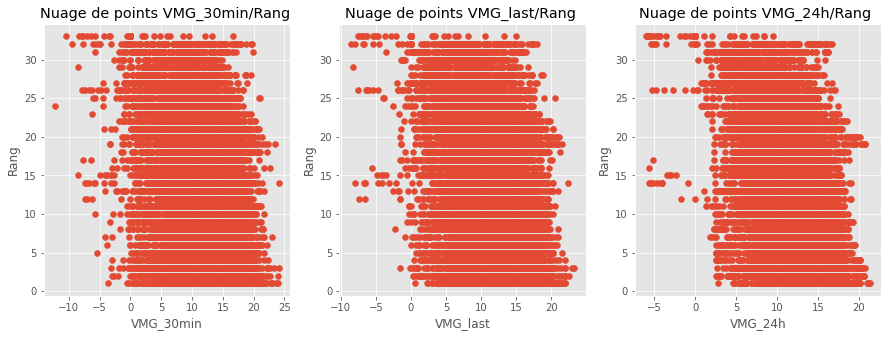

```python
# Nuage de points
fig, ax = plt.subplots(1,3, figsize=(15,5))
for i, col in enumerate(['VMG_30min', 'VMG_last', 'VMG_24h']):
    ax[i].scatter(df_[col], df_['Rang'])
    ax[i].set_xlabel(col)
    ax[i].set_ylabel('Rang')
    ax[i].set_title(f'Nuage de points {col}/Rang ');
```

Dans la régression linéaire simple (avec une seule covariable), le coefficient de détermination R^2 est égal au carré du coefficient de corrélation de Pearson r entre la variable indépendante X et la variable dépendante Y.  
Le test de Fisher (test de significativité globale des coefficients de régression) permet de tester si notre régression est globalement significative ou pas. L'hypothèse nulle est la nullité de tous les coefficients de régression.  
Le test de Student (test de significativité individuelle des coefficients de régression) permet de tester si un coefficient de régression est significatif ou pas. L'hypothèse nulle est la nullité de ce coefficient de régression.  
Le test de Jarque-Bera vérifie l'adéquation (conformité) d'une distribution empirique à la distribution gaussienne. L'hypothèse nulle est l'adéquation des données à une loi normale. Les moments d'ordre 3 et 4, respectivement Skewness (coefficient d'asymetrie) et Kurtosis (coefficient d'aplatissement) donnent une idée sur la forme de la courbe de la distribution des erreurs.

```python
# add intercept to the model
X = sm.add_constant(df_['VMG_30min'])
# fit model
y = df_['Rang']
reg = sm.OLS(y, X)
reg_fit = reg.fit()
print(reg_fit.summary())
```

```
                            OLS Regression Results
==============================================================================
Dep. Variable:                   Rang   R-squared:                       0.076
Model:                            OLS   Adj. R-squared:                  0.076
Method:                 Least Squares   F-statistic:                     1114.
Date:                Thu, 06 Jan 2022   Prob (F-statistic):          9.34e-235
Time:                        07:33:53   Log-Likelihood:                -47775.
No. Observations:               13607   AIC:                         9.555e+04
Df Residuals:                   13605   BIC:                         9.557e+04
Df Model:                           1
Covariance Type:            nonrobust
==============================================================================
                 coef    std err          t      P>|t|      [0.025      0.975]
------------------------------------------------------------------------------
const         20.4836      0.183    111.958      0.000      20.125      20.842
VMG_30min     -0.4967      0.015    -33.370      0.000      -0.526      -0.467
==============================================================================
Omnibus:                     2157.961   Durbin-Watson:                   0.433
Prob(Omnibus):                  0.000   Jarque-Bera (JB):              490.680
Skew:                          -0.022   Prob(JB):                    2.82e-107
Kurtosis:                       2.071   Cond. No.                         32.6
==============================================================================

Notes:
[1] Standard Errors assume that the covariance matrix of the errors is correctly specified.
```

Le coefficient d'adéquation est petit (0.076). C'est à dire, que uniquement 7.6% de la variabilité de la variable réponse Y est expliquée par le modèle. Donc, notre modèle a un pouvoir prédictif faible.  
La p-value du test de Fisher est très inférieure à 5%. On rejette donc l'hypothèse nulle du test. Ainsi, notre régression est globalement significative. Egalement, la corrélation entre la variable cible et la covariance est significative.  
La p-value du test de Student associée à l'intercept est très inférieure à 5%. Par conséquent, l'intercept du modèle linéaire est significatif.  
La p-value du test de Student associée à la pente est très inférieure à 5%. Par conséquent, la pente du modèle linéaire est significative.  
La p-value du test de Jarque-Bera est trop inférieure à 5%. On rejette donc l'hypothèse nulle selon laquelle les erreurs de la régresssion linéaire suivent une loi normale.

```python
# add intercept to the model
X = sm.add_constant(df_['VMG_last'])
# fit model
y = df_['Rang']
reg = sm.OLS(y, X)
reg_fit = reg.fit()
print(reg_fit.summary())
```

```
                            OLS Regression Results
==============================================================================
Dep. Variable:                   Rang   R-squared:                       0.092
Model:                            OLS   Adj. R-squared:                  0.092
Method:                 Least Squares   F-statistic:                     1380.
Date:                Thu, 06 Jan 2022   Prob (F-statistic):          8.51e-288
Time:                        07:33:53   Log-Likelihood:                -47653.
No. Observations:               13607   AIC:                         9.531e+04
Df Residuals:                   13605   BIC:                         9.533e+04
Df Model:                           1
Covariance Type:            nonrobust
==============================================================================
                 coef    std err          t      P>|t|      [0.025      0.975]
------------------------------------------------------------------------------
const         21.5912      0.194    111.035      0.000      21.210      21.972
VMG_last      -0.5913      0.016    -37.149      0.000      -0.623      -0.560
==============================================================================
Omnibus:                     1871.774   Durbin-Watson:                   0.435
Prob(Omnibus):                  0.000   Jarque-Bera (JB):              462.682
Skew:                          -0.037   Prob(JB):                    3.39e-101
Kurtosis:                       2.100   Cond. No.                         34.7
==============================================================================

Notes:
[1] Standard Errors assume that the covariance matrix of the errors is correctly specified.
```

Le coefficient d'adéquation est petit (0.092). C'est à dire, que uniquement 9.2% de la variabilité de la variable réponse Y est expliquée par le modèle. Donc, notre modèle a un pouvoir prédictif faible.  
La p-value du test de Fisher est très inférieure à 5%. On rejette donc l'hypothèse nulle du test. Ainsi, notre régression est globalement significative. Egalement, la corrélation entre la variable cible et la covariance est significative.  
La p-value du test de Student associée à l'intercept est très inférieure à 5%. Par conséquent, l'intercept du modèle linéaire est significatif.  
La p-value du test de Student associée à la pente est très inférieure à 5%. Par conséquent, la pente du modèle linéaire est significative.  
La p-value du test de Jarque-Bera est trop inférieure à 5%. On rejette donc l'hypothèse nulle selon laquelle les erreurs de la régresssion linéaire suivent une loi normale.

```python
# add intercept to the model
X = sm.add_constant(df_['VMG_24h'])
# fit model
y = df_['Rang']
reg = sm.OLS(y, X)
reg_fit = reg.fit()
print(reg_fit.summary())
```

```
                            OLS Regression Results
==============================================================================
Dep. Variable:                   Rang   R-squared:                       0.133
Model:                            OLS   Adj. R-squared:                  0.133
Method:                 Least Squares   F-statistic:                     2091.
Date:                Thu, 06 Jan 2022   Prob (F-statistic):               0.00
Time:                        07:33:53   Log-Likelihood:                -47338.
No. Observations:               13607   AIC:                         9.468e+04
Df Residuals:                   13605   BIC:                         9.469e+04
Df Model:                           1
Covariance Type:            nonrobust
==============================================================================
                 coef    std err          t      P>|t|      [0.025      0.975]
------------------------------------------------------------------------------
const         24.3905      0.220    111.103      0.000      23.960      24.821
VMG_24h       -0.8464      0.019    -45.724      0.000      -0.883      -0.810
==============================================================================
Omnibus:                     1294.724   Durbin-Watson:                   0.429
Prob(Omnibus):                  0.000   Jarque-Bera (JB):              397.836
Skew:                          -0.081   Prob(JB):                     4.08e-87
Kurtosis:                       2.178   Cond. No.                         39.0
==============================================================================

Notes:
[1] Standard Errors assume that the covariance matrix of the errors is correctly specified.
```

Le coefficient d'adéquation est petit (0.133). C'est à dire, que uniquement 13.3% de la variabilité de la variable réponse Y est expliquée par le modèle. Donc, notre modèle a un pouvoir prédictif faible.  
La p-value du test de Fisher est très inférieure à 5%. On rejette donc l'hypothèse nulle du test. Ainsi, notre régression est globalement significative. Egalement, la corrélation entre la variable cible et la covariance est significative.  
La p-value du test de Student associée à l'intercept est très inférieure à 5%. Par conséquent, l'intercept du modèle linéaire est significatif.  
La p-value du test de Student associée à la pente est très inférieure à 5%. Par conséquent, la pente du modèle linéaire est significative.  
La p-value du test de Jarque-Bera est trop inférieure à 5%. On rejette donc l'hypothèse nulle selon laquelle les erreurs de la régresssion linéaire suivent une loi normale.

### Régression sur les données agrégées (par nom de voilier) entre le rang et les différentes vitesses utiles (VMG) des voiliers

Une autre approche serait d'effectuer la régression avec les mêmes variable mais cette fois sur des données regroupées par skipper/voilier. Pour cela, on calcule le rang moyen et la VMG moyenne pour chaque voilier.  
**NB** : Il est plus judicieux dans notre cas d'utiliser la moyenne arithmétique pour calculer la VMG moyenne et pas la moyenne harmonique

```python
#Construnction du dataframe qui donne le rang moyen et la vitesse moyenne par Voilier
df_agg=df_[['Rang','VMG_30min', 'VMG_last', 'VMG_24h', 'Numéro du voilier']] \
        .groupby(by='Numéro du voilier').agg({'Rang':'mean','VMG_30min':'mean', 'VMG_last':'mean', 'VMG_24h':'mean'})
df_agg.head()
```

| Numéro du voilier | Rang | VMG_30min | VMG_last | VMG_24h |
| --- | --- | --- | --- | --- |
| 1 | 5.576200 | 12.396033 | 12.509186 | 12.381420 |
| 2 | 16.323591 | 12.234029 | 12.271816 | 12.131106 |
| 4 | 10.283871 | 11.331613 | 11.444516 | 11.406452 |
| 6 | 6.914894 | 9.719149 | 10.140426 | 9.614894 |
| 7 | 16.306889 | 11.114614 | 11.118998 | 10.937996 |

**NB** : Il aurait été plus judicieux de supprimer les données des skippers qui n'ont pas fini la course. Or, en faisant cela, on aura un nombre d'observations inférieur à 30 et donc notre modèle de régression fournira des résultats biaisées.

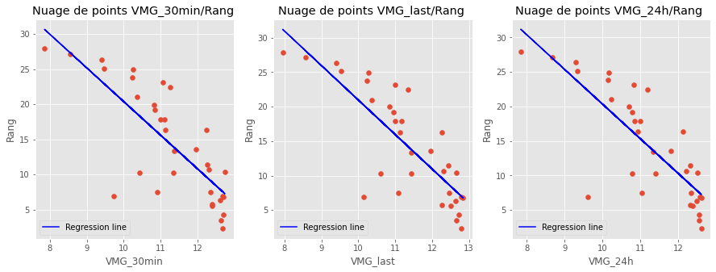

```python
# Nuage de points
fig, ax = plt.subplots(1,3, figsize=(15,5))
for i, col in enumerate(['VMG_30min', 'VMG_last', 'VMG_24h']):
    lin_reg = LinearRegression()
    lin_reg.fit(df_agg[col].to_frame(), df_agg['Rang'])
    y_pred = lin_reg.predict(df_agg[col].to_frame())
    ax[i].scatter(df_agg[col], df_agg['Rang'])
    ax[i].plot(df_agg[col], y_pred, 'b', label='Regression line')
    ax[i].set_xlabel(col)
    ax[i].set_ylabel('Rang')
    ax[i].set_title(f'Nuage de points {col}/Rang ')
    ax[i].legend(loc='lower left')
plt.show()
```

```python
for i, col in enumerate(['VMG_30min', 'VMG_last', 'VMG_24h']):
    print(f"Le coefficient de détermination de la régression de la variable Rang sur la variable {col} est : {lin_reg.score(df_agg[col].to_frame(), df_agg['Rang']):.2%}")
```

```
Le coefficient de détermination de la régression de la variable Rang sur la variable VMG_30min est : 61.37%
Le coefficient de détermination de la régression de la variable Rang sur la variable VMG_last est : 65.44%
Le coefficient de détermination de la régression de la variable Rang sur la variable VMG_24h est : 65.48%
```

On obtient un bon coefficient d'adéquation pour les 3 régressions.

## KMeans sur les caractéristiques techniques des voiliers

L’algorithme des K-moyennes (K-means) est un algorithme d'apprentissage non supervisé ayant pour objectif de séparer les données en groupes homogènes ayant des caractéristiques communes.

```python
# Extraction de certaines caractéristiques des voiliers
df1_ = df1[['Longueur', 'Largeur', "Tirant d'eau", 'Déplacement (poids)', 'Foils', 'Hauteur mât', 'Voile quille', \
            'Surface de voiles au près', 'Surface de voiles au portant']]
df1_.dropna(inplace=True)
df1_.reset_index(drop=True, inplace=True)
```

### Prétraitement des données

Pour appliquer la méthode Kmeans, il faut que les variables soient numérique. Or, on a 2 variables qualitatives, à savoir 'Foils' et 'Voile quille'.  
La variable 'Foils' a deux modalités. On peut donc faire un recodage numérique binaire.  
La variable 'Voile quille' a plusieurs modalités sans ordre naturel (variable qualitative nominale). Recoder numériquement ces modalités n'est pas la meilleure solution (car le recodage numérique sous-entend un classement des modalités ce qui va à l'encontre de la nature de la variable de type nominale). La meilleure solution serait donc l'encodage à chaud (one-hot-encoding). Cette variable sera éclatée en variables binaires (dummy variables) dont le nombre est égal au nombre des modalités de la variable de départ. Or, les catégories de cette variable sont nombreuses et non équilibrées. Par conséquent, on propose de regrouper les modalités faiblement représentées dans la classe 'Autre matériel'.  
**NB** : Dans le cadre du one-hot-encoding, la création de variables indicatrices dont le nombre est égal au nombre des modalités de la variable de départ crée un problème de multicolinéarité (la valeur d'une variable binaire peut toujours être déduite des n-1 valeurs de variables binaires restanes) qui impacte la méthode KMeans. Or, ceci ne présentera pas un problème dans notre cas puisqu'on appliquera par la suite l'ACP qui élimine la multicolinéarité.

```python
# Recodage de la variable 'Foils' en binaire
df1_['Foils'] = df1_['Foils'].apply(lambda x: 1 if x=='Oui' else 0)
df1_

# Création de nouvelles classes à partir des anciennes catégories pour la variable 'Voile quille'
df1_['Voile quille'] = df1_['Voile quille'].replace(list(df1_['Voile quille'].value_counts()[2:].index), 'autre matériel')
# One-hot-encoding
lb = LabelBinarizer()
df0 = pd.DataFrame(lb.fit_transform(df1_['Voile quille'].to_numpy()), columns=lb.classes_)
df0 = df0[['acier forgé', 'acier', 'autre matériel']]
df1_.drop('Voile quille', axis=1, inplace=True)
df1_ = df1_.join(df0, how='right')
```

On élimine l'effet d'échelle en standardisant nos variables

```python
scaler = StandardScaler()
scaled = scaler.fit(df1_) # Compute the mean and std to be used for later scaling
std_df1_ = pd.DataFrame(scaled.transform(df1_), index=df1_.index, columns=df1_.columns)
```

```python
std_df1_.head()
```

|  | Longueur | Largeur | Tirant d'eau | Déplacement (poids) | Foils | Hauteur mât | Surface de voiles au près | Surface de voiles au portant | acier forgé | acier | autre matériel |
| --- | --- | --- | --- | --- | --- | --- | --- | --- | --- | --- | --- |
| 0 | 0.267261 | 0.912657 | 0.0 | -2.303388 | 0.0 | 0.654654 | 0.565424 | -0.399104 | -0.816497 | -0.707107 | 1.658312 |
| 1 | -3.741657 | 0.587482 | 0.0 | 1.714149 | 0.0 | -0.654654 | -0.726974 | -0.603772 | 1.224745 | -0.707107 | -0.603023 |
| 2 | -3.741657 | -1.363566 | 0.0 | 1.714149 | 0.0 | 0.654654 | -1.373172 | -0.194435 | -0.816497 | 1.414214 | -0.603023 |
| 3 | 0.267261 | 0.587482 | 0.0 | -0.294619 | 0.0 | 0.654654 | 0.242325 | -0.808441 | -0.816497 | -0.707107 | 1.658312 |
| 4 | 0.267261 | 0.912657 | 0.0 | -0.294619 | 0.0 | 0.654654 | 0.565424 | 0.214902 | -0.816497 | 1.414214 | -0.603023 |

### Détermination du nombre de voisins optimal et application de la méthode KMeans

On souhaite déterminer l'hyperparamètre k (nombre de clusters) optimal pour la méthode KMeans. Pour cela, on trace pour plusieurs valeurs de k, le score du clustering. On choisira comme mètrique pour évaluer le score : la distortion totale. Pour un cluster $C$ de centroide $c$ entouré par les points $(x^{c}_i)_{i=0}$, la distortion $d(c)$ se définit comme : $$ d(c) = \sum_i |x_i - c|^2, $$ En utilisant 'la méthode du coude', on détermine k optimal.

```
[270.0, 218.49849640173937, 172.62273749071133, 137.87340627599048, 108.05805922806084, 97.41845460535134, 86.07203091005682, 75.05116579858922, 67.66483089984156]
```

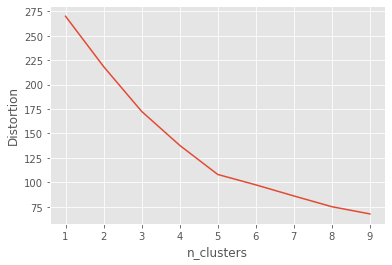

```python
def distortion(data, clustering):
    X_new = clustering.fit_transform(data)
    distortion = clustering.inertia_
    return distortion

min_k = 1
max_k = 10
elbow_scores = [distortion(std_df1_, KMeans(n_clusters=k, random_state=1)) for k in list(range(min_k, max_k))]
print(elbow_scores)
plt.plot(list(range(min_k, max_k)), elbow_scores)
plt.xlabel("n_clusters")
plt.ylabel("Distortion");
```

On remarque une cassure dans la courbe de distortion pour la valeur k=5. La méthode du coude nous dit alors que le nombre de clusters optimal est 5.

```python
kmeans_algo = KMeans(n_clusters=5, init='k-means++', random_state=1, verbose=1) # Compute k-means clustering (fit estimator)
X_new = kmeans_algo.fit_transform(df1_) # transform X to cluster-distance space
print(f"\n\nLe nombre d'itérations : {kmeans_algo.n_iter_}", end='\n\n')
print(f"Les labels (numéro du cluster) des observations : {kmeans_algo.labels_}", end='\n\n\n')
print(f"Les centroïdes des clusters : {kmeans_algo.cluster_centers_}", end='\n\n\n')
print(f"L'inertie (variance totale) est égale à : {kmeans_algo.inertia_}", end='\n\n')  ## inertia(SSE)
```

[output not shown]

[output cut: 26 more lines]

```


Les centroïdes des clusters : [[1.82800e+01 5.67500e+00 4.50000e+00 7.85000e+00 0.00000e+00 2.90000e+01
  3.32500e+02 7.00000e+02 5.00000e-01 5.00000e-01 0.00000e+00]
 [1.82600e+01 5.71750e+00 4.50000e+00 8.60000e+00 0.00000e+00 2.83750e+01
  2.82500e+02 5.61875e+02 2.50000e-01 2.50000e-01 5.00000e-01]
 [1.82800e+01 5.78750e+00 4.50000e+00 7.96250e+00 0.00000e+00 2.88750e+01
  3.35000e+02 5.81250e+02 5.00000e-01 2.50000e-01 2.50000e-01]
 [1.82800e+01 5.69000e+00 4.50000e+00 7.97000e+00 0.00000e+00 2.84000e+01
  2.94000e+02 6.18000e+02 5.00000e-01 3.00000e-01 2.00000e-01]
 [1.82800e+01 5.50000e+00 4.50000e+00 8.25000e+00 0.00000e+00 2.75000e+01
  2.65000e+02 4.80000e+02 0.00000e+00 1.00000e+00 0.00000e+00]]


L'inertie (variance totale) est égale à : 20233.310499999996
```

### Réalisation d'une ACP pour visualiser les résultats

En grande dimension (11 variables dans notre cas), il n'est pas possible de visualiser les résultats de KMeans.  
Une solution serait de faire une réduction de dimension en appliquant l'ACP afin de créer 2 variables synthétiques (axes factoriels).  
**NB** : On a appliqué l'ACP uniquement dans un but de visualisation.

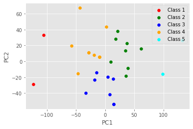

```python
pca = PCA(n_components=2) #2-dimensional PCA
df_pca = pd.DataFrame(pca.fit_transform(df1_), index=std_df1_.index, columns=['PC1', 'PC2'])
plt.scatter(df_pca.loc[kmeans_algo.labels_==0, 'PC1'], df_pca.loc[kmeans_algo.labels_==0, 'PC2'], label='Class 1', c='red')
plt.scatter(df_pca.loc[kmeans_algo.labels_==1, 'PC1'], df_pca.loc[kmeans_algo.labels_==1, 'PC2'], label='Class 2', c='green')
plt.scatter(df_pca.loc[kmeans_algo.labels_==2, 'PC1'], df_pca.loc[kmeans_algo.labels_==2, 'PC2'], label='Class 3', c='blue')
plt.scatter(df_pca.loc[kmeans_algo.labels_==3, 'PC1'], df_pca.loc[kmeans_algo.labels_==3, 'PC2'], label='Class 4', c='orange')
plt.scatter(df_pca.loc[kmeans_algo.labels_==4, 'PC1'], df_pca.loc[kmeans_algo.labels_==4, 'PC2'], label='Class 5', c='cyan')
plt.xlabel('PC1')
plt.ylabel('PC2')
plt.legend(loc='upper right');
```

## Impact de la présence d'un foil sur le classement et sur les différentes vitesses utiles des voiliers

```python
# Construction d'un Dataframe composé des colonnes 'Foils' et 'Rang final'
df_tmp = df_fus.loc[df_fus['Date_classement']=='2021-01-27 14:00:00',['Numéro du voilier','Foils','Rang']].rename(columns={'Rang':'Rang final'})
df_tmp.set_index('Numéro du voilier', inplace=True)

# Construction d'un Dataframe composé des colonnes 'VMG_last_mean' et 'VMG_last_max'
df_agg = df_[['Rang', 'VMG_last', 'Numéro du voilier']] \
        .groupby(by='Numéro du voilier').agg({'Rang':'mean','VMG_last':['mean','max']})
df_agg.columns = ['Rang', 'VMG_last_mean', 'VMG_last_max']

# Fusion des 2 DataFrames
df_f = pd.merge(df_tmp, df_agg, left_on='Numéro du voilier', right_on='Numéro du voilier')
df_f.drop('Rang', axis=1, inplace=True)
df_f.head()
```

| Numéro du voilier | Foils | Rang final | VMG_last_mean | VMG_last_max |
| --- | --- | --- | --- | --- |
| 8 | OUI | 14 | 11.345511 | 20.7 |
| 79 | OUI | 1 | 12.780793 | 23.3 |
| 59 | OUI | 4 | 12.653862 | 22.5 |
| 10 | OUI | 3 | 12.786848 | 20.6 |
| 2 | OUI | 11 | 12.271816 | 22.4 |

Une boite-à-moustaches donne des informations graphiques sur la position (à travers la médiane) ,la dispersion (à travers l'écart interquartile et la distance entre les moustaches), l'asymétrie (en comparant la médiane à la moyenne) et les points aberrants (points représentés au-delà des moustaches).  
Dans notre cas, on représente le boxplot de la variable 'Rang final' selon les 2 modalités de la variable 'Foils' pour voir s'il y une relation significative entre les 2 variables.

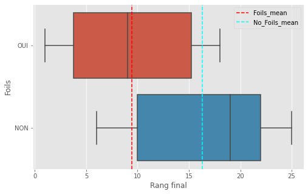

```python
plt.figure(figsize=(8,5))
sns.boxplot(x=df_f['Rang final'], y=df_f['Foils'])
plt.axvline(x=df_f.loc[df_f['Foils']=='OUI','Rang final'].mean(), color='red', linestyle='--', label='Foils_mean')
plt.axvline(x=df_f.loc[df_f['Foils']=='NON','Rang final'].mean(), color='cyan', linestyle='--', label='No_Foils_mean')
plt.legend(loc='upper right');
```

On remarque que les 2 plots n'ont pas d'outliers et à peu près la même dispersion. La distribution du 2ème groupe (No_Foils) a une assymètrie négative (moyenne < médiane) et la distribution du 1er groupe est symètrique.  
La médiane du 1er groupe (Foils) est inférieure au quartile inférieure du 2ème groupe (No_Foils). Par conséquent, on peut conclure que la présence d'un foils influence significativement le rang final des skippers. En effet, les voiliers équipés d'un foils ont tendance à avoir de meilleurs classements.

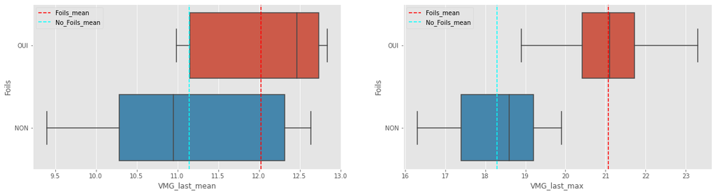

```python
plt.figure(figsize=(20,5))
plt.subplot(1,2,1)
sns.boxplot(x=df_f['VMG_last_mean'], y=df_f['Foils'])
plt.axvline(x=df_f.loc[df_f['Foils']=='OUI','VMG_last_mean'].mean(), color='red', linestyle='--', label='Foils_mean')
plt.axvline(x=df_f.loc[df_f['Foils']=='NON','VMG_last_mean'].mean(), color='cyan', linestyle='--', label='No_Foils_mean')
plt.legend(loc='upper left')
plt.subplot(1,2,2)
sns.boxplot(x=df_f['VMG_last_max'], y=df_f['Foils'])
plt.axvline(x=df_f.loc[df_f['Foils']=='OUI','VMG_last_max'].mean(), color='red', linestyle='--', label='Foils_mean')
plt.axvline(x=df_f.loc[df_f['Foils']=='NON','VMG_last_max'].mean(), color='cyan', linestyle='--', label='No_Foils_mean')
plt.legend(loc='upper left');
```

- Pour la variable 'VMG_last_mean' :  
  On remarque que les 2 plots n'ont pas d'outliers.  
  La distribution du 2ème groupe (No_Foils) a une plus grande dispersion et une assymètrie positive (moyenne > médiane) contrairement à la distribution du 1er groupe qui a une assymètrie négative (moyenne < médiane).  
  La médiane du 2ème groupe (No_Foils) est inférieure au quartile inférieure du 1er groupe (Foils). Par conséquent, on peut conclure que la présence d'un foils influence significativement la VMG (calculée depuis le dernier classement) moyenne des voiliers. En effet, les voiliers équipés d'un foils ont une VMG moyenne significativement plus grande.
- Pour la variable 'VMG_last_max' :  
  On remarque que les 2 plots n'ont pas d'outliers.  
  La distribution du 2ème groupe (No_Foils) a une plus grande dispersion et une assymètrie négative (moyenne < médiane) contrairement à la distribution du 1er groupe qui est symètrique.  
  La médiane du 2ème groupe (No_Foils) est inférieure à la moustache inférieure (minimum de la série) du 1er groupe (Foils). Par conséquent, on peut conclure que la présence d'un foils inmpacte significativement la VMG (calculée depuis le dernier classement) maximale des voiliers. En effet, les voiliers équipés d'un foils peuvent atteindre une VMG maximale significativement plus grande que celle atteinte par les voiliers sans foils.

## Visualisation de la distance parcourue par voilier

```python
# Calcul de la distance parcourue par voilier juqu'au '2021-01-27 14:00' (juste avant l'arrivée du premier skipper)
df0 = df_fus[['Distance_last','Nom du skipper']].groupby(by='Nom du skipper').agg({'Distance_last':'sum'}).rename(columns={'Distance_last': 'Distance cumulée'})
df0.head()
```

| Nom du skipper | Distance cumulée |
| --- | --- |
| Alan Roura | 23545.2 |
| Alex Thomson | 8240.0 |
| Alexia Barrier | 20173.5 |
| Ari Huusela | 20773.6 |
| Armel Tripon | 26449.8 |

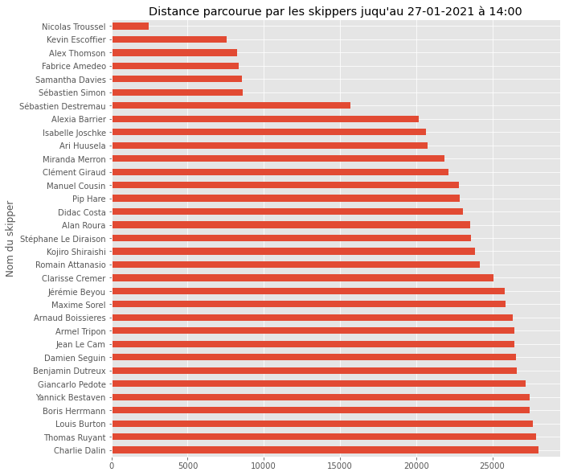

```python
# Visualisation
df0_sort = df0.sort_values(by='Distance cumulée', ascending=False)
df0_sort.plot(kind='barh', figsize=(10,10), title="Distance parcourue par les skippers juqu'au 27-01-2021 à 14:00", legend=None);
```

## Analyse de séries chronologiques

### Visualisation de la progression du rang de skippers dans le temps

```python
df_piv = pd.pivot_table(df_[['Date_classement','Rang','Nom du skipper']], values='Rang' ,columns='Nom du skipper', index='Date_classement')
df_piv
```

| Nom du skipper Date_classement | Alan Roura | Alex Thomson | Alexia Barrier | Ari Huusela | Armel Tripon | Arnaud Boissieres | Benjamin Dutreux | Boris Herrmann | Charlie Dalin | Clarisse Cremer | Clément Giraud | Damien Seguin | Didac Costa | Fabrice Amedeo | Giancarlo Pedote | Isabelle Joschke | Jean Le Cam | Jérémie Beyou | Kevin Escoffier | Kojiro Shiraishi | Louis Burton | Manuel Cousin | Maxime Sorel | Miranda Merron | Nicolas Troussel | Pip Hare | Romain Attanasio | Samantha Davies | Stéphane Le Diraison | … |
| --- | --- | --- | --- | --- | --- | --- | --- | --- | --- | --- | --- | --- | --- | --- | --- | --- | --- | --- | --- | --- | --- | --- | --- | --- | --- | --- | --- | --- | --- | --- |
| 2020-11-08 17:00:00 | 22.0 | 4.0 | 31.0 | 32.0 | 7.0 | NaN | 23.0 | 5.0 | 2.0 | 20.0 | 30.0 | 17.0 | 27.0 | 24.0 | 13.0 | 15.0 | 18.0 | 1.0 | 14.0 | 12.0 | 11.0 | 26.0 | 16.0 | 25.0 | 6.0 | 28.0 | 21.0 | 10.0 | 19.0 | … |
| 2020-11-08 21:00:00 | 27.0 | 6.0 | 32.0 | 30.0 | 3.0 | 28.0 | 21.0 | 7.0 | 5.0 | 20.0 | 25.0 | 17.0 | 26.0 | 33.0 | 19.0 | 15.0 | 9.0 | 1.0 | 11.0 | 12.0 | 8.0 | 24.0 | 16.0 | 23.0 | 2.0 | 29.0 | 22.0 | 10.0 | 18.0 | … |
| 2020-11-09 04:00:00 | 23.0 | 19.0 | 29.0 | 30.0 | 6.0 | 26.0 | 12.0 | 22.0 | 17.0 | 13.0 | 31.0 | 3.0 | 24.0 | 33.0 | 8.0 | 15.0 | 2.0 | 4.0 | 20.0 | 14.0 | 11.0 | 27.0 | 1.0 | 25.0 | 5.0 | 28.0 | 10.0 | 21.0 | 9.0 | … |
| 2020-11-09 08:00:00 | 16.0 | 11.0 | 31.0 | 26.0 | 24.0 | 20.0 | 6.0 | 29.0 | 25.0 | 8.0 | 28.0 | 3.0 | 14.0 | 33.0 | 7.0 | 12.0 | 1.0 | 17.0 | 27.0 | 10.0 | 18.0 | 13.0 | 2.0 | 15.0 | 19.0 | 30.0 | 5.0 | 22.0 | 4.0 | … |
| 2020-11-09 11:00:00 | 27.0 | 10.0 | 32.0 | 22.0 | 25.0 | 30.0 | 6.0 | 19.0 | 21.0 | 17.0 | 23.0 | 1.0 | 16.0 | 33.0 | 9.0 | 18.0 | 3.0 | 8.0 | 14.0 | 24.0 | 28.0 | 13.0 | 2.0 | 15.0 | 4.0 | 29.0 | 5.0 | 11.0 | 7.0 | … |
| ... | ... | ... | ... | ... | ... | ... | ... | ... | ... | ... | ... | ... | ... | ... | ... | ... | ... | ... | ... | ... | ... | ... | ... | ... | ... | ... | ... | ... | ... | … |
| 2021-01-26 21:00:00 | 16.0 | NaN | 24.0 | 25.0 | 11.0 | 15.0 | 9.0 | 2.0 | 1.0 | 12.0 | 22.0 | 6.0 | 20.0 | NaN | 7.0 | NaN | 8.0 | 14.0 | NaN | 17.0 | 3.0 | 21.0 | 10.0 | 23.0 | NaN | 19.0 | 13.0 | NaN | 18.0 | … |
| 2021-01-27 04:00:00 | 16.0 | NaN | 24.0 | 25.0 | 11.0 | 15.0 | 9.0 | 2.0 | 1.0 | 12.0 | 23.0 | 6.0 | 20.0 | NaN | 7.0 | NaN | 8.0 | 14.0 | NaN | 17.0 | 3.0 | 21.0 | 10.0 | 22.0 | NaN | 19.0 | 13.0 | NaN | 18.0 | … |
| 2021-01-27 08:00:00 | 16.0 | NaN | 24.0 | 25.0 | 11.0 | 15.0 | 9.0 | 3.0 | 1.0 | 12.0 | 23.0 | 6.0 | 20.0 | NaN | 7.0 | NaN | 8.0 | 14.0 | NaN | 17.0 | 2.0 | 21.0 | 10.0 | 22.0 | NaN | 19.0 | 13.0 | NaN | 18.0 | … |
| 2021-01-27 11:00:00 | 16.0 | NaN | 24.0 | 25.0 | 11.0 | 15.0 | 9.0 | 3.0 | 1.0 | 12.0 | 23.0 | 6.0 | 20.0 | NaN | 7.0 | NaN | 8.0 | 14.0 | NaN | 17.0 | 2.0 | 21.0 | 10.0 | 22.0 | NaN | 19.0 | 13.0 | NaN | 18.0 | … |
| 2021-01-27 14:00:00 | 16.0 | NaN | 24.0 | 25.0 | 11.0 | 15.0 | 9.0 | 3.0 | 1.0 | 12.0 | 23.0 | 6.0 | 20.0 | NaN | 7.0 | NaN | 8.0 | 14.0 | NaN | 17.0 | 2.0 | 21.0 | 10.0 | 22.0 | NaN | 19.0 | 13.0 | NaN | 18.0 | … |

479 rows × 33 columns

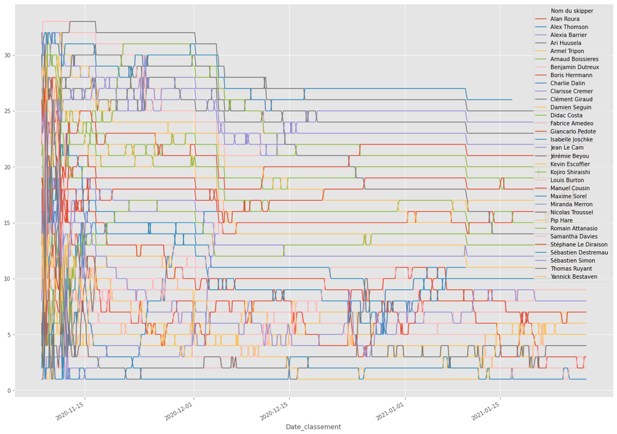

```python
df_piv.plot(figsize=(20, 15));
```

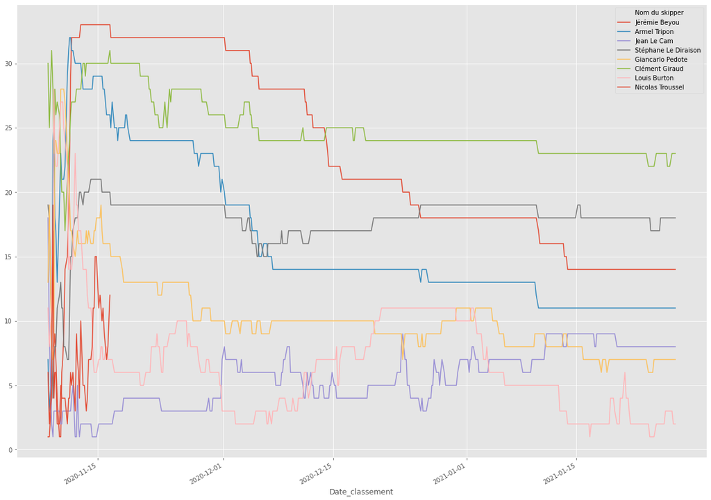

```python
# Visualisation (plus claire) sur un échantillon réduit de skippers
df_piv.loc[:,sample(list(df_piv.columns),8)].plot(figsize=(20, 15));
```

### Visualisation de la progression de la distance parcourue (depuis le dernier classement) par les skippers dans le temps

```python
df_piv = pd.pivot_table(df_[['Date_classement','Distance_last','Nom du skipper']], values='Distance_last' ,columns='Nom du skipper', index='Date_classement')
df_piv.loc['2020-11-08 21:00:00', 'Arnaud Boissieres'] = np.nan #valeur aberrante qui gâche l'échelle de visualisation
df_piv
```

| Nom du skipper Date_classement | Alan Roura | Alex Thomson | Alexia Barrier | Ari Huusela | Armel Tripon | Arnaud Boissieres | Benjamin Dutreux | Boris Herrmann | Charlie Dalin | Clarisse Cremer | Clément Giraud | Damien Seguin | Didac Costa | Fabrice Amedeo | Giancarlo Pedote | Isabelle Joschke | Jean Le Cam | Jérémie Beyou | Kevin Escoffier | Kojiro Shiraishi | Louis Burton | Manuel Cousin | Maxime Sorel | Miranda Merron | Nicolas Troussel | Pip Hare | Romain Attanasio | Samantha Davies | Stéphane Le Diraison | … |
| --- | --- | --- | --- | --- | --- | --- | --- | --- | --- | --- | --- | --- | --- | --- | --- | --- | --- | --- | --- | --- | --- | --- | --- | --- | --- | --- | --- | --- | --- | --- |
| 2020-11-08 17:00:00 | 28.9 | 32.9 | 23.1 | 20.2 | 35.4 | NaN | 27.2 | 34.0 | 35.0 | 28.2 | 20.8 | 28.6 | 24.1 | 25.8 | 30.3 | 32.4 | 28.4 | 35.6 | 32.1 | 33.2 | 32.3 | 24.1 | 28.9 | 24.6 | 34.3 | 23.8 | 26.4 | 32.4 | 30.1 | … |
| 2020-11-08 21:00:00 | 56.3 | 56.6 | 46.7 | 47.4 | 70.2 | NaN | 58.1 | 60.5 | 59.4 | 57.2 | 48.7 | 56.0 | 52.8 | 23.4 | 54.1 | 60.8 | 56.3 | 67.6 | 64.2 | 61.1 | 63.0 | 50.5 | 56.9 | 51.8 | 71.8 | 52.8 | 57.1 | 60.6 | 55.6 | … |
| 2020-11-09 04:00:00 | 74.4 | 94.1 | 68.5 | 48.0 | 100.4 | 73.0 | 77.5 | 97.7 | 104.6 | 87.0 | 44.1 | 72.7 | 66.9 | 29.4 | 83.3 | 82.2 | 71.1 | 93.4 | 100.8 | 77.2 | 94.7 | 67.0 | 76.1 | 65.1 | 103.0 | 70.5 | 75.0 | 95.8 | 66.5 | … |
| 2020-11-09 08:00:00 | 38.4 | 34.8 | 34.1 | 31.9 | 47.2 | 37.9 | 35.7 | 45.4 | 46.5 | 38.6 | 31.3 | 37.3 | 32.1 | 0.8 | 40.4 | 42.8 | 38.9 | 49.4 | 44.8 | 37.1 | 43.8 | 34.7 | 35.0 | 33.2 | 48.4 | 38.0 | 33.9 | 43.8 | 34.0 | … |
| 2020-11-09 11:00:00 | 28.7 | 18.7 | 27.5 | 26.0 | 18.1 | 29.3 | 20.1 | 21.6 | 20.6 | 25.0 | 30.0 | 22.2 | 24.4 | 0.0 | 20.2 | 18.5 | 30.5 | 22.1 | 22.4 | 25.6 | 24.9 | 26.4 | 21.6 | 26.6 | 34.2 | 21.9 | 21.0 | 25.9 | 27.0 | … |
| ... | ... | ... | ... | ... | ... | ... | ... | ... | ... | ... | ... | ... | ... | ... | ... | ... | ... | ... | ... | ... | ... | ... | ... | ... | ... | ... | ... | ... | ... | … |
| 2021-01-26 21:00:00 | 50.8 | NaN | 50.5 | 45.1 | 74.0 | 59.6 | 66.2 | 70.8 | 44.8 | 38.6 | 45.6 | 64.6 | 51.6 | NaN | 76.9 | NaN | 66.5 | 47.1 | NaN | 51.0 | 70.1 | 48.3 | 71.3 | 34.9 | NaN | 49.3 | 53.0 | NaN | 50.6 | … |
| 2021-01-27 04:00:00 | 97.7 | NaN | 89.2 | 83.7 | 121.0 | 97.3 | 130.1 | 107.0 | 94.0 | 87.1 | 53.9 | 116.9 | 93.9 | NaN | 128.4 | NaN | 119.1 | 112.5 | NaN | 91.5 | 117.9 | 92.6 | 130.6 | 77.9 | NaN | 92.7 | 85.9 | NaN | 99.3 | … |
| 2021-01-27 08:00:00 | 61.9 | NaN | 45.8 | 49.0 | 50.5 | 60.1 | 60.5 | 65.4 | 76.5 | 26.8 | 38.0 | 65.0 | 49.7 | NaN | 84.2 | NaN | 68.0 | 62.0 | NaN | 57.4 | 72.4 | 53.8 | 74.9 | 46.9 | NaN | 56.3 | 49.3 | NaN | 62.2 | … |
| 2021-01-27 11:00:00 | 44.5 | NaN | 33.6 | 33.4 | 37.9 | 46.0 | 49.3 | 41.5 | 58.3 | 25.7 | 31.7 | 51.3 | 38.8 | NaN | 60.0 | NaN | 52.2 | 44.4 | NaN | 50.8 | 54.9 | 42.2 | 52.8 | 36.1 | NaN | 43.6 | 36.9 | NaN | 49.0 | … |
| 2021-01-27 14:00:00 | 44.2 | NaN | 27.3 | 32.5 | 55.4 | 34.8 | 47.9 | 49.9 | 57.2 | 25.2 | 30.3 | 51.0 | 41.0 | NaN | 62.1 | NaN | 57.0 | 46.8 | NaN | 47.3 | 53.3 | 41.1 | 50.4 | 35.5 | NaN | 44.8 | 34.2 | NaN | 41.1 | … |

479 rows × 33 columns

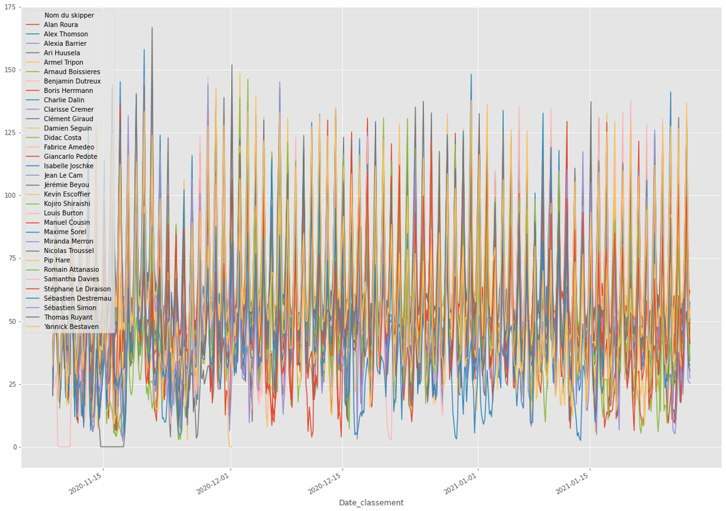

```python
df_piv.plot(figsize=(20, 15));
```

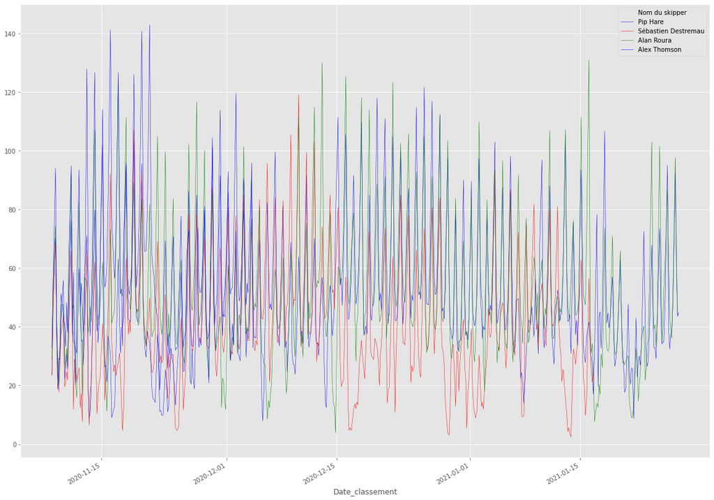

```python
# Visualisation (plus claire) sur un échantillon réduit de skippers
df_piv.loc[:,sample(list(df_piv.columns),4)].plot(figsize=(20, 15), color=['b','r','g','b'], linewidth=0.5);
```

# 6) Visualisation du parcours des voiliers sur la carte

```python
! pip install plotly
```

```python
# Visualisation du parcours de 3 voiliers sur la carte
init_notebook_mode(connected=True)

voiliers = []
voiliers.append(df_.loc[df_['Numéro du voilier']==17,['Latitude','Longitude','Rang']].sample(frac=0.4, replace=True))
voiliers.append(df_.loc[df_['Numéro du voilier']==79,['Latitude','Longitude','Rang']].sample(frac=0.4, replace=True))
voiliers.append(df_.loc[df_['Numéro du voilier']==18,['Latitude','Longitude','Rang']].sample(frac=0.4, replace=True))

data = []
for i in range(3):
    data.append(go.Scattergeo(lon = voiliers[i]['Longitude'], lat = voiliers[i]['Latitude'],
                              marker = dict(size = 5/voiliers[i]['Rang'])))

layout = dict(title = 'Parcours des voiliers numéro 17, 79 et 18', geo = dict(showcountries = True))

fig = {'data': data, 'layout': layout}
iplot(fig, filename='Visualisation_du_parcours_des_voiliers_sur_la_carte')
```

[interactive chart not shown]